# Normalization Performance Analysis for the Paired MSK Data Set

Yannick Dueren, Johannes Lederer, Li-Xuan Qin

# Setup

```r
settings <- list(
  # If true sets all other settings to TRUE
  all=F,
  # Application of the full DANA pipeline to the benchmark data
  bench.DANA=T,
  # Application of the full DANA pipeline to the test data
  test.DANA=T,
  # Generate interactive plots of co-expression structures
  investigate.coexpression=F,
  # Comparison of coexpression estimation methods
  compare.corr.methods=F,
  # Full Pipeline comparison of two correlation methods
  compare.two.methods=F,
  # Compare DANA results for different cutoff choices
  compare.cutoffs=T,
  # Perform Differential Expression Analysis for test and benchmark data sets
  perform.DEA=T,
  # Generate paper figures
  generate.paper.figs=T,
  # Specify if paper figures are exported
  export.figures = T,
  # Path for file exports
  paper.fig.path = "../../danawriteup/figs/",
  # Clears environment
  debug=TRUE
)
if(settings$all) {
  settings$bench.DANA=TRUE
  settings$test.DANA=TRUE
  settings$investigate.coexpression=TRUE
  settings$compare.corr.methods=TRUE
  settings$compare.two.methods=TRUE
  settings$generate.paper.figs=TRUE
}
if(settings$generate.paper.figs) {
  settings$bench.DANA=TRUE
  settings$test.DANA=TRUE
}
if(settings$debug) rm(list=ls()[ls()!="settings"])
```

## Parameter configuration

The `config` list contains all parameters for the analysis. Remember to *always set the working directory* and the paths to the data/external files prior to running the code.

```r
config <- list(
  # working directory
  working.dir = "C:/Users/Yannick/Google Drive/projects/normalization/paperSupplement",
  DANA.path = "./R/DANA.R",

  ## Data
  case.name = "MSK",
  # Read count data file for the full MSK data set
  data.file.path = "data/MSKDatasets.RData",
  # miRNA coordinates (chromosome and base pair location on chromosome)
  coords.file = "data/coords.msk.RData",
  # Restrict the analysis to a subtype
  # Available: "all", "PMFH", and "MXF"
  data.subtype = "all",

  ## Normalization Methods
  # Specify which normalization methods will be applied
  norm.apply.TC = TRUE,
  norm.apply.UQ = TRUE,
  norm.apply.med = TRUE,
  norm.apply.TMM = TRUE,
  norm.apply.DESeq = TRUE,
  norm.apply.PoissonSeq = TRUE,
  norm.apply.QN = TRUE,
  norm.apply.RUV = TRUE,

  # thresholds for zero-expressed, poorly-expressed and well-expressed genes
  t.zero = 2,  # zero-expressed in [0, t.zero)
  t.poor = 10,  # poorly-expressed in [t.zero, t.poor]
  t.well = 2^7,  # well-expressed in [t.well, inf)
  # distance threshold for clustering
  cluster.threshold = 10000,
  # preprocessing data transformation type: none ("n"), modified log2 ("log2"),
  # or cube root ("cube") available
  preprocess.transform = "log2",

  ## Correlation Estimation for positive and negative controls
  # Available methods | Tuning parameter calibration schemes
  # "mb"              | "cv", "aic", "bic", "av"
  # "huge.mb"         | "ric", "stars"
  # "glasso"          | "ric", "stars", "ebic"
  # "fastggm"         | none
  # "pearson"         | none
  # "spearman"        | none

  # Positive Controls
  corr.method.pos = "mb",
  tuning.criterion.pos = "bic",
  # Negative Controls
  corr.method.neg = "pearson",
  tuning.criterion.neg = "",
  # Generate plots within DANA
  generate.plots = FALSE  # generate comparison plots
)
```

Configuration for the differential expression analysis

```r
config.DEA <- list(
  ## Data
  case.name = "MSK",

  ## Normalization Methods
  # Specify which normalization methods will be applied
  norm.apply.TC = TRUE,
  norm.apply.UQ = TRUE,
  norm.apply.med = TRUE,
  norm.apply.TMM = TRUE,
  norm.apply.DESeq = TRUE,
  norm.apply.PoissonSeq = TRUE,
  norm.apply.QN = TRUE,
  norm.apply.RUV = TRUE,

  # Significance level for DEA
  alpha = 0.01,
  # Plots
  generate.volcano.plot = TRUE,
  generate.meanvar.plot = TRUE,
  # Use q-values (adjusted p-values) instead of p-values
  q.values = FALSE,
  # RUV reduces the parameter size. Reduce DEA result to RUV genes?
  perform.subsetting = TRUE
)
```

## Load Packages

Load all required R libraries/packages.

```r
# Set working directory
setwd(config$working.dir)
# DANA functions
source(config$DANA.path)
# Libraries
library(openxlsx)  # read excel files
library(corrplot) # For mixed correlation plots
library(cowplot) # Arrange plots
library(RColorBrewer) # Colors
library(latex2exp) # for latex in axis labels
library(ggcorrplot) # ggplot2 correlation plots
```

# Load Data

## Load the dataset under study

We load the data set into memory and reduce the set one one subtype (MXF or PMFH) if necessary.

```r
# Load the p x n matrix of read counts into the workspace
load(config$data.file.path)
# Transform gene names to lower case
rownames(benchmark) <- tolower(rownames(benchmark))
rownames(test) <- tolower(rownames(test))

# Rename
test.RC <- test
bench.RC <- benchmark

# Inspect
cat("Dimensions of test data: ", dim(test.RC), "\n")
```

```
## Dimensions of test data:  1033 54
```

```r
cat("Dimensions of benchmark data: ", dim(bench.RC), "\n")
```

```
## Dimensions of benchmark data:  1033 54
```

```r
# Set sample groups
groups <- ifelse(substr(colnames(test.RC), 1, 3)=="MXF", "MXF", "PMFH")

## Reduce to subtype
if(config$data.subtype != "all") {
  test.RC <- test.RC[, groups == config$data.subtype]
  bench.RC <- bench.RC[, groups == config$data.subtype]
  groups <- groups[groups == config$data.subtype]
}
```

## miRNA Coordinates

We intend to map all genes in the data to their locations in the genome. Therefore, we build data frames mapping miRNAs to their coordinates on the genome. This coordinate is expressed through chromosome number and base-pair location.

The data frame `coords` uniquely maps each mature and star miRNA to their respective position on the genome. The name of the `coords` data frame entries corresponds to the mature/star name. The data frame has the following entries:

- loc.index : Ordering index of all precursors on the genome
- chr : The chromosome idnetifier on which the gene is located
- start : Number of the first base pair of the miRNA on the chromosome
- end : Number of the last base pair of the miRNA on the chromosome
- corresponding : The name of the corresponding mature or star miRNA, respectively

```r
load(config$coords.file)
```

## Remove genes that cannot be found in the coordinates data frame

Some miRNAs map to multiple locations of sequence families. We named the sequence family with a parenthesis that reflects the number of members from all the different genomic locations (e.g. hsa-let-7a(3)). These miRNAs cannot be uniquely mapped to the genome, therefore we must exclude these from the location based analysis.

```r
# only consider genes that are present in the coordinate data frame
genes.in.coords <- rownames(coords)[na.omit(match(rownames(test.RC), rownames(coords)))]
cat(dim(test.RC)[1]-length(genes.in.coords), " genes not found in coords. Reducing data set to ", length(genes.in.coords), "genes.\n")
```

```
## 72  genes not found in coords. Reducing data set to  961 genes.
```

```r
# test data set
test.RC <- test.RC[genes.in.coords, ]
# benchmark data set
bench.RC <- bench.RC[genes.in.coords, ]
genes <- rownames(test.RC)
rm(genes.in.coords)
```

## Examine the Data

First, we investigate the distribution of mean miRNA expression of the data.

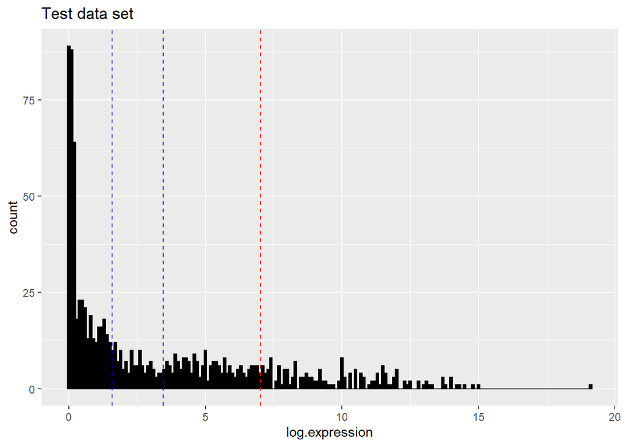

```r
# Histogram plot test data set
par(mfrow=c(1,1))
df <- data.frame(log.expression=log2(rowMeans(test.RC)+1))
print(ggplot(df, aes(x=log.expression)) +
        geom_histogram(binwidth = .1, color="black", fill="black") +
        geom_vline(xintercept = log2(config$t.zero+1), color="blue", linetype="dashed") +
        geom_vline(xintercept = log2(config$t.poor+1), color="blue", linetype="dashed") +
        geom_vline(xintercept = log2(config$t.well+1), color="red",  linetype="dashed") +
        ggtitle("Test data set"))
```

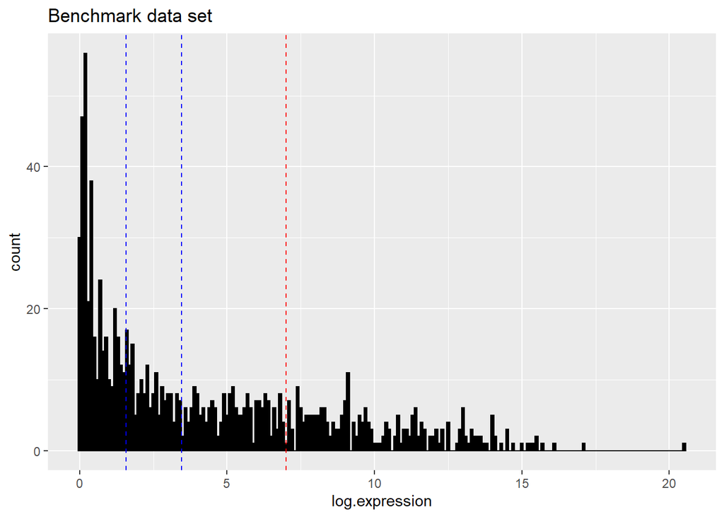

```r
rm(df)

# Histogram plot benchmark data set
par(mfrow=c(1,1))
df <- data.frame(log.expression=log2(rowMeans(bench.RC)+1))
print(ggplot(df, aes(x=log.expression)) +
        geom_histogram(binwidth = .1, color="black", fill="black") +
        geom_vline(xintercept = log2(config$t.zero+1), color="blue", linetype="dashed") +
        geom_vline(xintercept = log2(config$t.poor+1), color="blue", linetype="dashed") +
        geom_vline(xintercept = log2(config$t.well+1), color="red",  linetype="dashed") +
        ggtitle("Benchmark data set"))
```

```r
rm(df)
```

We observe that there is a large proportion of poorly-expressed genes. Some of them have extremely low or zero mean expression which corresponds to essentially zero reads.

# Comparison of Coexpression Estimation Methods

```r
if(settings$compare.corr.methods) {
  ## Preprocessing for test data set
  genes.test <- rownames(test.RC)

  # Apply Normalization
  test.norm <- normalize(test.RC,
                         groups=groups,
                         name="test",
                         apply.TC=T,
                         apply.UQ=T,
                         apply.med=T,
                         apply.TMM=T,
                         apply.DESeq=T,
                         apply.PoissonSeq=T,
                         apply.QN=T,
                         apply.RUV=T)

  # Define Controls
  pre.res <- define.controls(test.RC,
                             t.zero=config$t.zero,
                             t.poor=config$t.poor,
                             t.well=config$t.well,
                             t.cluster=config$cluster.threshold,
                             coords=coords,
                             clusters=NULL)
  pos.controls.test <- pre.res$genes.pos
  neg.controls.test <- pre.res$genes.neg
  clusters.test <- pre.res$clusters



  ## Estimate partial correlations and cc+ metric using DANA

  # mb (bic)
  cat("Estimating Models using method: mb.bic\n")
  DANA.test.mb.bic.res <- DANA(data.RC=test.RC,
                       data.norm=test.norm,
                       pos.controls=pos.controls.test,
                       neg.controls=neg.controls.test,
                       clusters=clusters.test,
                       coords=coords,
                       case.name="test",
                       generate.plots=F,
                       preprocess.transform="log2",
                       corr.method.pos="mb",
                       tuning.criterion.pos="bic",
                       corr.method.neg="pearson",
                       tuning.criterion.neg="")

  # mb(aic)
  cat("Estimating Models using method: mb.aic\n")
  DANA.test.mb.aic.res <- DANA(data.RC=test.RC,
                       data.norm=test.norm,
                       pos.controls=pos.controls.test,
                       neg.controls=neg.controls.test,
                       clusters=clusters.test,
                       coords=coords,
                       case.name="test",
                       generate.plots=F,
                       preprocess.transform="log2",
                       corr.method.pos="mb",
                       tuning.criterion.pos="aic",
                       corr.method.neg="pearson",
                       tuning.criterion.neg="")

  # mb (av)
  cat("Estimating Models using method: mb.av\n")
  DANA.test.mb.av.res <- DANA(data.RC=test.RC,
                       data.norm=test.norm,
                       pos.controls=pos.controls.test,
                       neg.controls=neg.controls.test,
                       clusters=clusters.test,
                       coords=coords,
                       case.name="test",
                       generate.plots=F,
                       preprocess.transform="log2",
                       corr.method.pos="mb",
                       tuning.criterion.pos="av",
                       corr.method.neg="pearson",
                       tuning.criterion.neg="")

  # mb (cv)
  cat("Estimating Models using method: mb.cv\n")
  DANA.test.mb.cv.res <- DANA(data.RC=test.RC,
                       data.norm=test.norm,
                       pos.controls=pos.controls.test,
                       neg.controls=neg.controls.test,
                       clusters=clusters.test,
                       coords=coords,
                       case.name="test",
                       generate.plots=F,
                       preprocess.transform="log2",
                       corr.method.pos="mb",
                       tuning.criterion.pos="cv",
                       corr.method.neg="pearson",
                       tuning.criterion.neg="")

  # glasso (ric)
  cat("Estimating Models using method: glasso(ric)\n")
  DANA.test.glasso.ric.res <- DANA(data.RC=test.RC,
                       data.norm=test.norm,
                       pos.controls=pos.controls.test,
                       neg.controls=neg.controls.test,
                       clusters=clusters.test,
                       coords=coords,
                       case.name="test",
                       generate.plots=F,
                       preprocess.transform="log2",
                       corr.method.pos="glasso",
                       tuning.criterion.pos="ric",
                       corr.method.neg="pearson",
                       tuning.criterion.neg="")

  # glasso (stars)
  cat("Estimating Models using method: glasso(stars)\n")
  DANA.test.glasso.stars.res <- DANA(data.RC=test.RC,
                       data.norm=test.norm,
                       pos.controls=pos.controls.test,
                       neg.controls=neg.controls.test,
                       clusters=clusters.test,
                       coords=coords,
                       case.name="test",
                       generate.plots=F,
                       preprocess.transform="log2",
                       corr.method.pos="glasso",
                       tuning.criterion.pos="stars",
                       corr.method.neg="pearson",
                       tuning.criterion.neg="")

  # huge.mb (ric)
  cat("Estimating Models using method: huge.mb.ric\n")
  DANA.test.huge.mb.ric.res <- DANA(data.RC=test.RC,
                       data.norm=test.norm,
                       pos.controls=pos.controls.test,
                       neg.controls=neg.controls.test,
                       clusters=clusters.test,
                       coords=coords,
                       case.name="test",
                       generate.plots=F,
                       preprocess.transform="log2",
                       corr.method.pos="huge.mb",
                       tuning.criterion.pos="ric",
                       corr.method.neg="pearson",
                       tuning.criterion.neg="")

  # huge.mb (stars)
  cat("Estimating Models using method: huge.mb.stars\n")
  DANA.test.huge.mb.stars.res <- DANA(data.RC=test.RC,
                       data.norm=test.norm,
                       pos.controls=pos.controls.test,
                       neg.controls=neg.controls.test,
                       clusters=clusters.test,
                       coords=coords,
                       case.name="test",
                       generate.plots=F,
                       preprocess.transform="log2",
                       corr.method.pos="huge.mb",
                       tuning.criterion.pos="stars",
                       corr.method.neg="pearson",
                       tuning.criterion.neg="")
```

```r
  # FastGGM
  cat("Estimating Models using method: fastggm\n")
  DANA.test.fastggm.res <- DANA(data.RC=test.RC,
                       data.norm=test.norm,
                       pos.controls=pos.controls.test,
                       neg.controls=neg.controls.test,
                       clusters=clusters.test,
                       coords=coords,
                       case.name="test",
                       generate.plots=F,
                       preprocess.transform="log2",
                       corr.method.pos="fastggm",
                       tuning.criterion.pos="",
                       corr.method.neg="pearson",
                       tuning.criterion.neg="")

  # Pearson correlations
  cat("Estimating Models using method: pearson\n")
  DANA.test.pearson.res <- DANA(data.RC=test.RC,
                       data.norm=test.norm,
                       pos.controls=pos.controls.test,
                       neg.controls=neg.controls.test,
                       clusters=clusters.test,
                       coords=coords,
                       case.name="test",
                       generate.plots=F,
                       preprocess.transform="log2",
                       corr.method.pos="pearson",
                       tuning.criterion.pos="",
                       corr.method.neg="pearson",
                       tuning.criterion.neg="")

  # Spearman correlations
  cat("Estimating Models using method: spearman\n")
  DANA.test.spearman.res <- DANA(data.RC=test.RC,
                       data.norm=test.norm,
                       pos.controls=pos.controls.test,
                       neg.controls=neg.controls.test,
                       clusters=clusters.test,
                       coords=coords,
                       case.name="test",
                       generate.plots=F,
                       preprocess.transform="log2",
                       corr.method.pos="spearman",
                       tuning.criterion.pos="",
                       corr.method.neg="pearson",
                       tuning.criterion.neg="")


  # Fix normalization method names (remove "test." from names)
  rownames(DANA.test.mb.bic.res$metrics) <- substr(rownames(DANA.test.mb.bic.res$metrics), 6, 20)
  rownames(DANA.test.mb.aic.res$metrics) <- substr(rownames(DANA.test.mb.aic.res$metrics), 6, 20)
  rownames(DANA.test.mb.cv.res$metrics) <- substr(rownames(DANA.test.mb.cv.res$metrics), 6, 20)
  rownames(DANA.test.mb.av.res$metrics) <- substr(rownames(DANA.test.mb.av.res$metrics), 6, 20)
  rownames(DANA.test.glasso.ric.res$metrics) <- substr(rownames(DANA.test.glasso.ric.res$metrics), 6, 20)
  rownames(DANA.test.glasso.stars.res$metrics) <- substr(rownames(DANA.test.glasso.stars.res$metrics), 6, 20)
  rownames(DANA.test.huge.mb.ric.res$metrics) <- substr(rownames(DANA.test.huge.mb.ric.res$metrics), 6, 20)
  rownames(DANA.test.huge.mb.stars.res$metrics) <- substr(rownames(DANA.test.huge.mb.stars.res$metrics), 6, 20)
  rownames(DANA.test.fastggm.res$metrics) <- substr(rownames(DANA.test.fastggm.res$metrics), 6, 20)
  rownames(DANA.test.pearson.res$metrics) <- substr(rownames(DANA.test.pearson.res$metrics), 6, 20)
  rownames(DANA.test.spearman.res$metrics) <- substr(rownames(DANA.test.spearman.res$metrics), 6, 20)


  ## Display results
  par(mfrow=c(1,1))

  # # Display mean correlation reduction in negative controls
  # compare.test.mcr <- cbind(DANA.test.mb.bic.res$metrics$mcr,
  #                           DANA.test.mb.aic.res$metrics$mcr,
  #                           DANA.test.mb.cv.res$metrics$mcr,
  #                           DANA.test.mb.av.res$metrics$mcr,
  #                           DANA.test.glasso.ric.res$metrics$mcr,
  #                           DANA.test.glasso.stars.res$metrics$mcr,
  #                           DANA.test.huge.mb.ric.res$metrics$mcr,
  #                           DANA.test.huge.mb.stars.res$metrics$mcr,
  #                           DANA.test.fastggm.res$metrics$mcr,
  #                           DANA.test.pearson.res$metrics$mcr,
  #                           DANA.test.spearman.res$metrics$mcr)
  # rownames(compare.test.mcr) <- rownames(DANA.test.mb.bic.res$metrics)
  # colnames(compare.test.mcr) <- c("mb.bic", "mb.aic", "mb.cv", "mb.av", "glasso.ric", "glasso.stars", "huge.mb.ric", "huge.mb.stars", "fastggm", "pearson", "spearman")
  # stargazer(compare.test.mcr, type="text", summary=FALSE, digits=5,
  #             title="Test data - mcr-", align=TRUE)
  # corrplot.mixed(cor(compare.test.mcr),lower="circle",upper="number")

  # Compute correlation of cc+ metric for different estimation methods
  compare.test.cc <- cbind(DANA.test.mb.bic.res$metrics$cc,
                           DANA.test.mb.aic.res$metrics$cc,
                           DANA.test.mb.cv.res$metrics$cc,
                           DANA.test.mb.av.res$metrics$cc,
                           DANA.test.glasso.ric.res$metrics$cc,
                           DANA.test.glasso.stars.res$metrics$cc,
                           DANA.test.huge.mb.ric.res$metrics$cc,
                           DANA.test.huge.mb.stars.res$metrics$cc,
                           DANA.test.fastggm.res$metrics$cc,
                           DANA.test.pearson.res$metrics$cc,
                           DANA.test.spearman.res$metrics$cc)
  rownames(compare.test.cc) <- rownames(DANA.test.mb.bic.res$metrics)
  colnames(compare.test.cc) <- c("mb.bic", "mb.aic", "mb.cv","mb.av", "glasso.ric", "glasso.stars", "huge.mb.ric", "huge.mb.stars", "fastggm", "pearson", "spearman")
  stargazer(compare.test.cc, type="text", summary=FALSE, digits=3,
              title="Test data - cc+", align=TRUE)
  corrplot.mixed(cor(compare.test.cc),lower="circle",upper="number")


  ## Display result statistics plot
  # MB (bic)
  p.test.mb.bic.stats <- plot.DANA.metrics(DANA.test.mb.bic.res$metrics, label.repel=TRUE) + ggtitle("mb (bic)")
  print(p.test.mb.bic.stats)
  # MB (aic)
  p.test.mb.aic.stats <- plot.DANA.metrics(DANA.test.mb.aic.res$metrics, label.repel=TRUE) + ggtitle("mb (aic)")
  print(p.test.mb.aic.stats)
  # MB (cv)
  p.test.mb.cv.stats <- plot.DANA.metrics(DANA.test.mb.cv.res$metrics, label.repel=TRUE) + ggtitle("mb (cv)")
  print(p.test.mb.cv.stats)
  # MB (av)
  p.test.mb.av.stats <- plot.DANA.metrics(DANA.test.mb.av.res$metrics, label.repel=TRUE) + ggtitle("mb (av)")
  print(p.test.mb.av.stats)
  # glasso (ric)
  p.test.glasso.ric.stats <- plot.DANA.metrics(DANA.test.glasso.ric.res$metrics, label.repel=TRUE) + ggtitle("glasso (ric)")
  print(p.test.glasso.ric.stats)
  # glasso (stars)
  p.test.glasso.stars.stats <- plot.DANA.metrics(DANA.test.glasso.stars.res$metrics, label.repel=TRUE) + ggtitle("glasso (stars)")
  print(p.test.glasso.stars.stats)
  # huge.mb (ric)
  p.test.huge.mb.ric.stats <- plot.DANA.metrics(DANA.test.huge.mb.ric.res$metrics, label.repel=TRUE) + ggtitle("huge.mb (ric)")
  print(p.test.huge.mb.ric.stats)
  # huge.mb (stars)
  p.test.huge.mb.stars.stats <- plot.DANA.metrics(DANA.test.huge.mb.stars.res$metrics, label.repel=TRUE) + ggtitle("huge.mb (stars)")
  print(p.test.huge.mb.stars.stats)
  # FastGGM
  p.test.fastggm.stats <- plot.DANA.metrics(DANA.test.fastggm.res$metrics, label.repel=TRUE) + ggtitle("FastGGM")
  print(p.test.fastggm.stats)
  # Pearson
  p.test.pearson.stats <- plot.DANA.metrics(DANA.test.pearson.res$metrics, label.repel=TRUE) + ggtitle("Pearson")
  print(p.test.pearson.stats)
  # Spearman
  p.test.spearman.stats <- plot.DANA.metrics(DANA.test.spearman.res$metrics, label.repel=TRUE) + ggtitle("Spearman")
  print(p.test.spearman.stats)
```

```r
}
```

# DANA - Performance Analysis of Normalization Methods

We apply the full analysis pipeline to the data set. This includes:

1. Apply the normalization methods to the raw counts.
2. Define positive and negative controls based on read counts.
3. Estimate the level of coexpression between miRNAs for each data set.
4. Compare pos and neg controls before and after normalization.

The following parameters are used:

- Case name: MSK
- Control definition:
  - Definition of negative controls, read count in [2, 10]
  - Definition of positive controls, read count in [128, inf]
  - Distance threshold for clustering: 10^{4}
- Data preprocessing transformation: log2
- Coexpression estimation:
  - Correlation estimation method for positive controls: mb
  - Correlation estimation tuning parameter calibration method for positive controls: bic
- Comparison statistics:
  - Generate plots? FALSE

## Benchmark Data Set

```r
if(settings$bench.DANA) {
  genes <- rownames(bench.RC)

  ## Apply Normalization
  data.norm <- normalize(X=bench.RC,
                         groups=groups,
                         name="benchmark",
                         apply.TC=config$norm.apply.TC,
                         apply.UQ=config$norm.apply.UQ,
                         apply.med=config$norm.apply.med,
                         apply.TMM=config$norm.apply.TMM,
                         apply.DESeq=config$norm.apply.DESeq,
                         apply.PoissonSeq=config$norm.apply.PoissonSeq,
                         apply.QN=config$norm.apply.QN,
                         apply.RUV=config$norm.apply.RUV)
  bench.norm <- data.norm

  ## Define Controls
  pre.res <- define.controls(bench.RC,
                             t.zero=config$t.zero,
                             t.poor=config$t.poor,
                             t.well=config$t.well,
                             t.cluster=config$cluster.threshold,
                             coords=coords,
                             clusters=NULL)
  pos.controls <- pre.res$genes.pos
  pos.controls.bench <- pre.res$genes.pos
  neg.controls <- pre.res$genes.neg
  neg.controls.bench <- pre.res$genes.neg
  clusters <- pre.res$clusters
  clusters.bench <- clusters

  # Apply DANA pipeline
  DANA.bench <- DANA(data.RC=bench.RC,
                     data.norm=bench.norm,
                     pos.controls=pos.controls.bench,
                     neg.controls=neg.controls.bench,
                     clusters=clusters.bench,
                     coords=coords,
                     case.name="benchmark",
                     generate.plots=config$generate.plots,
                     preprocess.transform=config$preprocess.transform,
                     corr.method.pos=config$corr.method.pos,
                     tuning.criterion.pos=config$tuning.criterion.pos,
                     corr.method.neg=config$corr.method.neg,
                     tuning.criterion.neg=config$tuning.criterion.neg)

  if(!config$generate.plots) {
    stargazer(DANA.bench$metrics, type="text", summary=FALSE, digits=4,
              title="Comparison statistics for the benchmark data set", align=TRUE)
  }
  iplot.bench <- iggplot.corr(DANA.bench$data.model$pos$corr, clusters=clusters.bench, title="Benchmark data set - Positive controls (un-normalized)", coords=coords)
  iplot.bench.TMM <- iggplot.corr(DANA.bench$norm.models$benchmark.TMM$pos$corr, clusters=clusters.bench, title="Benchmark data set - Positive controls (TMM)", coords=coords)
}
```

```
## 212 genes has been filtered because they contains too small number of reads across the experiments.Number of positive control markers with RC in [128, inf): 179
## Number of negative control markers with RC in [2, 10]: 120
## Estimating correlations for pos. and neg. controls for data set benchmark...done
## Estimating correlations for pos. and neg. controls for data set benchmark.TMM...done
## Estimating correlations for pos. and neg. controls for data set benchmark.DESeq...done
## Estimating correlations for pos. and neg. controls for data set benchmark.PoissonSeq...done
## Estimating correlations for pos. and neg. controls for data set benchmark.TC...done
## Estimating correlations for pos. and neg. controls for data set benchmark.Med...done
## Estimating correlations for pos. and neg. controls for data set benchmark.RUVg...done
## Estimating correlations for pos. and neg. controls for data set benchmark.RUVs...done
## Estimating correlations for pos. and neg. controls for data set benchmark.RUVr...done
## Estimating correlations for pos. and neg. controls for data set benchmark.UQ...done
## Estimating correlations for pos. and neg. controls for data set benchmark.QN...done
## Comparing models benchmark vs. benchmark.TMM....done
## Comparing models benchmark vs. benchmark.DESeq....done
## Comparing models benchmark vs. benchmark.PoissonSeq....done
## Comparing models benchmark vs. benchmark.TC....done
## Comparing models benchmark vs. benchmark.Med....done
## Comparing models benchmark vs. benchmark.RUVg....done
## Comparing models benchmark vs. benchmark.RUVs....done
## Comparing models benchmark vs. benchmark.RUVr....done
## Comparing models benchmark vs. benchmark.UQ....done
## Comparing models benchmark vs. benchmark.QN....done
##
## Comparison statistics for the benchmark data set
## ==================================
##                        cc    mcr
## ----------------------------------
##    benchmark.TMM     0.9606 0.6682
##   benchmark.DESeq    0.9605 0.6541
## benchmark.PoissonSeq 0.9627 0.6661
##     benchmark.TC     0.9553 0.5247
##    benchmark.Med     0.9036 0.4627
##    benchmark.RUVg    0.9797 0.4565
##    benchmark.RUVs    0.8403 0.6019
##    benchmark.RUVr    0.9373 0.6740
##     benchmark.UQ     0.9155 0.4903
##     benchmark.QN     0.9216 0.6573
## ----------------------------------
```

## Test Data Set

```r
if(settings$test.DANA) {
  genes <- rownames(test.RC)

  ## Apply Normalization
  data.norm <- normalize(test.RC,
                         groups=groups,
                         name="test",
                         apply.TC=config$norm.apply.TC,
                         apply.UQ=config$norm.apply.UQ,
                         apply.med=config$norm.apply.med,
                         apply.TMM=config$norm.apply.TMM,
                         apply.DESeq=config$norm.apply.DESeq,
                         apply.PoissonSeq=config$norm.apply.PoissonSeq,
                         apply.QN=config$norm.apply.QN,
                         apply.RUV=config$norm.apply.RUV)
  test.norm <- data.norm

  ## Define Controls
  pre.res <- define.controls(test.RC,
                             t.zero=config$t.zero,
                             t.poor=config$t.poor,
                             t.well=config$t.well,
                             t.cluster=config$cluster.threshold,
                             coords=coords,
                             clusters=NULL)
  pos.controls <- pre.res$genes.pos
  pos.controls.test <- pre.res$genes.pos
  neg.controls <- pre.res$genes.neg
  neg.controls.test <- pre.res$genes.neg
  clusters <- pre.res$clusters
  clusters.test <- clusters

  # Apply DANA pipeline
  DANA.test <- DANA(data.RC=test.RC,
                    data.norm=test.norm,
                    pos.controls=pos.controls.test,
                    neg.controls=neg.controls.test,
                    clusters=clusters.test,
                    coords=coords,
                    case.name="test",
                    generate.plots=config$generate.plots,
                    preprocess.transform=config$preprocess.transform,
                    corr.method.pos=config$corr.method.pos,
                    tuning.criterion.pos=config$tuning.criterion.pos,
                    corr.method.neg=config$corr.method.neg,
                    tuning.criterion.neg=config$tuning.criterion.neg)

  if(!config$generate.plots) {
    stargazer(DANA.test$metrics, type="text", summary=FALSE, digits=4,
              title="Comparison metrics for the test data set", align=TRUE)
  }
  iplot.test <- iggplot.corr(DANA.test$data.model$pos$corr, clusters=clusters.test, title="Test data set - Positive controls (un-normalized)", coords=coords)
  iplot.test.TMM <- iggplot.corr(DANA.test$norm.models$test.TMM$pos$corr, clusters=clusters.test, title="Test data set - Positive controls (TMM)", coords=coords)
}
```

```
## 313 genes has been filtered because they contains too small number of reads across the experiments.Number of positive control markers with RC in [128, inf): 115
## Number of negative control markers with RC in [2, 10]: 102
## Estimating correlations for pos. and neg. controls for data set test...done
## Estimating correlations for pos. and neg. controls for data set test.TMM...done
## Estimating correlations for pos. and neg. controls for data set test.DESeq...done
## Estimating correlations for pos. and neg. controls for data set test.PoissonSeq...done
## Estimating correlations for pos. and neg. controls for data set test.TC...done
## Estimating correlations for pos. and neg. controls for data set test.Med...done
## Estimating correlations for pos. and neg. controls for data set test.RUVg...done
## Estimating correlations for pos. and neg. controls for data set test.RUVs...done
## Estimating correlations for pos. and neg. controls for data set test.RUVr...done
## Estimating correlations for pos. and neg. controls for data set test.UQ...done
## Estimating correlations for pos. and neg. controls for data set test.QN...done
## Comparing models test vs. test.TMM....done
## Comparing models test vs. test.DESeq....done
## Comparing models test vs. test.PoissonSeq....done
## Comparing models test vs. test.TC....done
## Comparing models test vs. test.Med....done
## Comparing models test vs. test.RUVg....done
## Comparing models test vs. test.RUVs....done
## Comparing models test vs. test.RUVr....done
## Comparing models test vs. test.UQ....done
## Comparing models test vs. test.QN....done
##
## Comparison metrics for the test data set
## =============================
##                   cc    mcr
## -----------------------------
##    test.TMM     0.9551 0.5084
##   test.DESeq    0.9518 0.5208
## test.PoissonSeq 0.9604 0.5170
##     test.TC     0.9605 0.4140
##    test.Med     0.6819 0.3226
##    test.RUVg    0.9597 0.3577
##    test.RUVs    0.9203 0.2916
##    test.RUVr    0.8117 0.6538
##     test.UQ     0.7010 0.3315
##     test.QN     0.9377 0.4866
## -----------------------------
```

## Investigate Co-expression Structures

We compare the estimated co-expression structures for the test and benchmark dataset. Here, we take a look at the models for the un-normalized data as well as TMM-normalized data. Note that you cannot directly compare the graphs of benchmark with test data since the considered set of genes is not identical.

```r
if(settings$investigate.coexpression && settings$bench.DANA && settings$test.DANA) {
  htmltools::tagList(list(iplot.bench, iplot.bench.TMM, iplot.test, iplot.test.TMM))  # show plots in markdown
}
```

# Plot co-expressions using interactive plots

We compare the estimated co-expression structures for the test and benchmark dataset. Here, we take a look at the models for the un-normalized data as well as TMM-normalized data. Note that you cannot directly compare the graphs of benchmark with test data since the considered set of genes is not identical.

```r
if(settings$investigate.coexpression && settings$bench.DANA && settings$test.DANA) {
  # Generate additional results for pearson correlation
  DANA.test.pearson.res <- DANA(data.RC=test.RC,
                                data.norm=test.norm,
                                pos.controls=pos.controls.test,
                                neg.controls=neg.controls.test,
                                clusters=clusters.test,
                                coords=coords,
                                case.name="test",
                                generate.plots=F,
                                preprocess.transform="log2",
                                corr.method.pos="pearson",
                                tuning.criterion.pos="",
                                corr.method.neg="pearson",
                                tuning.criterion.neg="")

  iplot.pearson.bench <- iggplot.corr(DANA.test.pearson.res$data.model$pos$corr, clusters=clusters.bench, title="Benchmark data set - Positive controls (un-normalized) - Pearson Correlation", coords=coords)
  iplot.pearson.bench.TMM <- iggplot.corr(DANA.test.pearson.res$norm.models$test.TMM$pos$corr, clusters=clusters.bench, title="Benchmark data set - Positive controls (TMM)", coords=coords)
  iplot.bench <- iggplot.corr(DANA.bench$data.model$pos$corr, clusters=clusters.bench, title="Benchmark data set - Positive controls (un-normalized)", coords=coords)
  iplot.bench.TMM <- iggplot.corr(DANA.bench$norm.models$benchmark.TMM$pos$corr, clusters=clusters.bench, title="Benchmark data set - Positive controls (TMM)", coords=coords)
  iplot.test <- iggplot.corr(DANA.test$data.model$pos$corr, clusters=clusters.test, title="Test data set - Positive controls (un-normalized)", coords=coords)
  iplot.test.TMM <- iggplot.corr(DANA.test$norm.models$test.TMM$pos$corr, clusters=clusters.test, title="Test data set - Positive controls (TMM)", coords=coords)


  iplot.pearson.bench.neg <- iggplot.corr(DANA.test.pearson.res$data.model$neg$corr, clusters=clusters.bench, title="Benchmark data set - Negative controls (un-normalized) - Pearson Correlation", coords=coords)
  iplot.pearson.bench.TMM.neg <- iggplot.corr(DANA.test.pearson.res$norm.models$test.TMM$neg$corr, clusters=clusters.test, title="Benchmark data set - Negative controls (TMM)", coords=coords)
  iplot.bench.neg <- iggplot.corr(DANA.bench$data.model$neg$corr, clusters=clusters.bench, title="Benchmark data set - Negative controls (un-normalized)", coords=coords)
  iplot.bench.TMM.neg <- iggplot.corr(DANA.bench$norm.models$benchmark.TMM$neg$corr, clusters=clusters.bench, title="Benchmark data set - Negative controls (TMM)", coords=coords)
  iplot.test.neg <- iggplot.corr(DANA.test$data.model$neg$corr, clusters=clusters.test, title="Test data set - Negative controls (un-normalized)", coords=coords)
  iplot.test.TMM.neg <- iggplot.corr(DANA.test$norm.models$test.TMM$neg$corr, clusters=clusters.test, title="Test data set - Negative controls (TMM)", coords=coords)

  htmltools::tagList(list(iplot.pearson.bench.neg, iplot.pearson.bench.TMM.neg, iplot.bench.neg, iplot.bench.TMM.neg, iplot.test.neg, iplot.test.TMM.neg))  # show plots in markdown
  htmltools::tagList(list(iplot.pearson.bench.neg, iplot.pearson.bench.TMM.neg, iplot.bench.neg, iplot.bench.TMM.neg, iplot.test.neg, iplot.test.TMM.neg))  # show plots in markdown
}
```

# Comparison of two Co-expression Estimation Methods

In this section, we compare two methods for estimating the co-expression of miRNAs to each other. The methods can be chosen individually to positive and negative controls and include all available marginal and partial correaltion methods.

## Computation

```r
if(settings$compare.two.methods) {
  ## Setup
  show.plots <- TRUE
  # Method for estimating partial correlations
  method1.name <- "Partial Correlations (Meinshausen-Buehlmann, bic)"
  method1.pos <- "mb"
  tuning.method1.pos <- "bic"
  method1.neg <- "mb"
  tuning.method1.neg <- "bic"
  # Method for estimating marginal correlations
  method2.name <- "Marginal Correlations (Pearson)"
  method2.pos <- "mb"
  tuning.method2.pos <- "bic"
  method2.neg <- "pearson"
  tuning.method2.neg <- ""

  ## Apply Normalization
  data.norm <- normalize(test.RC,
                         groups=groups,
                         name="test",
                         apply.TC=config$norm.apply.TC,
                         apply.UQ=config$norm.apply.UQ,
                         apply.med=config$norm.apply.med,
                         apply.TMM=config$norm.apply.TMM,
                         apply.DESeq=config$norm.apply.DESeq,
                         apply.PoissonSeq=config$norm.apply.PoissonSeq,
                         apply.QN=config$norm.apply.QN,
                         apply.RUV=config$norm.apply.RUV)


  ## Define Controls
  # Define Polycistronic Clusters and Controls
  pre.res <- define.controls(test.RC,
                             t.zero=config$t.zero,
                             t.poor=config$t.poor,
                             t.well=config$t.well,
                             t.cluster=config$cluster.threshold,
                             coords=coords,
                             clusters=NULL)
  pos.controls <- pre.res$genes.pos
  neg.controls <- pre.res$genes.neg
  clusters <- pre.res$clusters
  rm(pre.res)




  ## Apply DANA pipeline
  # Method 1
  DANA.method1 <- DANA(data.RC=test.RC,
                       data.norm=data.norm,
                       pos.controls=pos.controls,
                       neg.controls=neg.controls,
                       clusters=clusters,
                       coords=coords,
                       case.name="test",
                       generate.plots=show.plots,
                       preprocess.transform=config$preprocess.transform,
                       corr.method.pos=method1.pos,
                       tuning.criterion.pos=tuning.method1.pos,
                       corr.method.neg=method1.neg,
                       tuning.criterion.neg=tuning.method1.neg)

  # Method 2
  DANA.method2 <- DANA(data.RC=test.RC,
                       data.norm=data.norm,
                       pos.controls=pos.controls,
                       neg.controls=neg.controls,
                       clusters=clusters,
                       coords=coords,
                       case.name="test",
                       generate.plots=show.plots,
                       preprocess.transform=config$preprocess.transform,
                       corr.method.pos=method2.pos,
                       tuning.criterion.pos=tuning.method2.pos,
                       corr.method.neg=method2.neg,
                       tuning.criterion.neg=tuning.method2.neg)

  if(!show.plots) {
    stargazer(DANA.method1$metrics, type="text", summary=FALSE, digits=4,
              title="Comparison statistics for the test data set", align=TRUE)
    stargazer(DANA.method2$metrics, type="text", summary=FALSE, digits=4,
              title="Comparison statistics for the test data set", align=TRUE)
  }

}
```

## Result Plots

```r
if(settings$compare.two.methods) {
  p.res.stats.method1 <- plot.DANA.metrics(DANA.method1$metrics, label.repel=TRUE) + ggtitle(method1.name)
  plot(p.res.stats.method1)

  p.res.stats.method2 <- plot.DANA.metrics(DANA.method2$metrics, label.repel=TRUE) + ggtitle(method2.name)
  plot(p.res.stats.method2)
}
```

# Comparison of DANA results for different choices of control cutoffs

We compare the results of the DANA appraoch for different choices of the control cutoffs. We test three different configurations and plot the resulting DANA metrics for preservation of biological effects and removal of handling effects. We observe only small differences/variation of the results even though the controls are chosen considerably different.

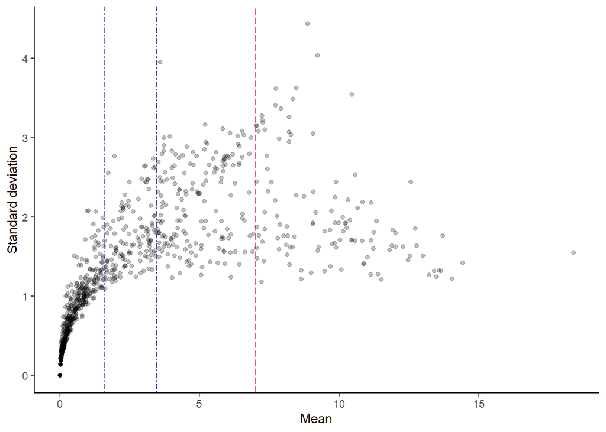

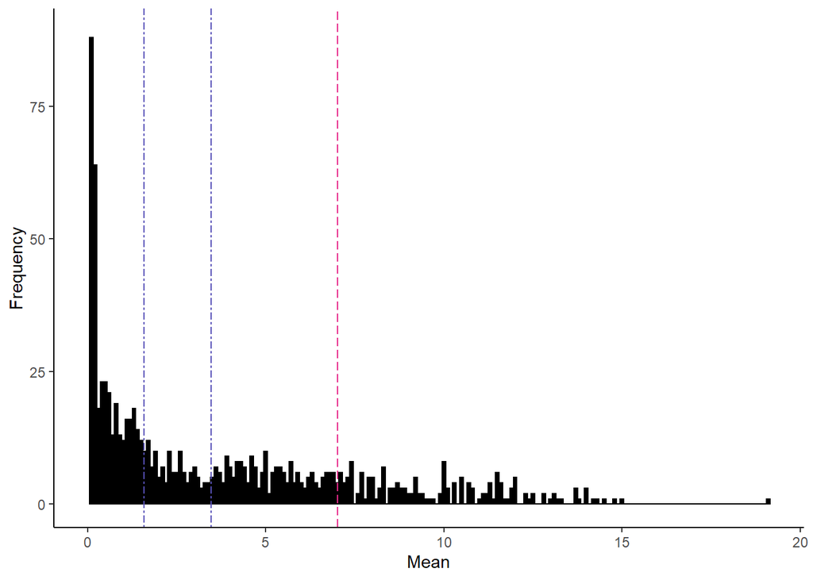

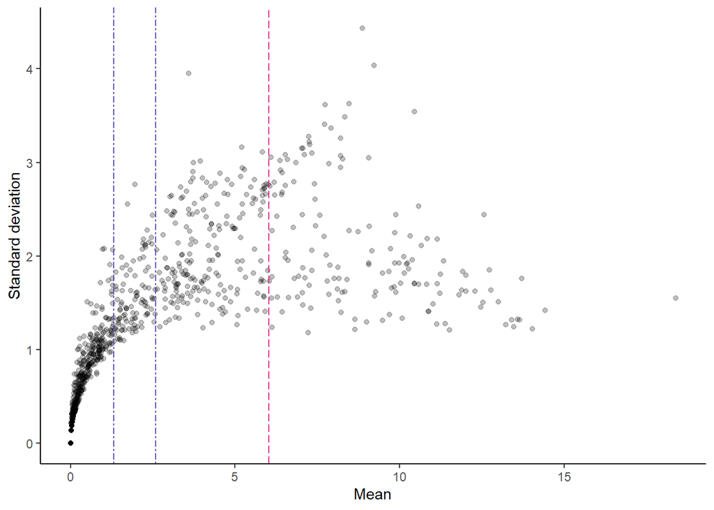

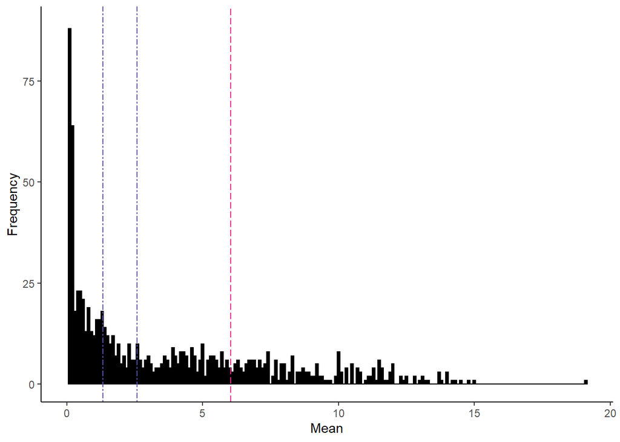

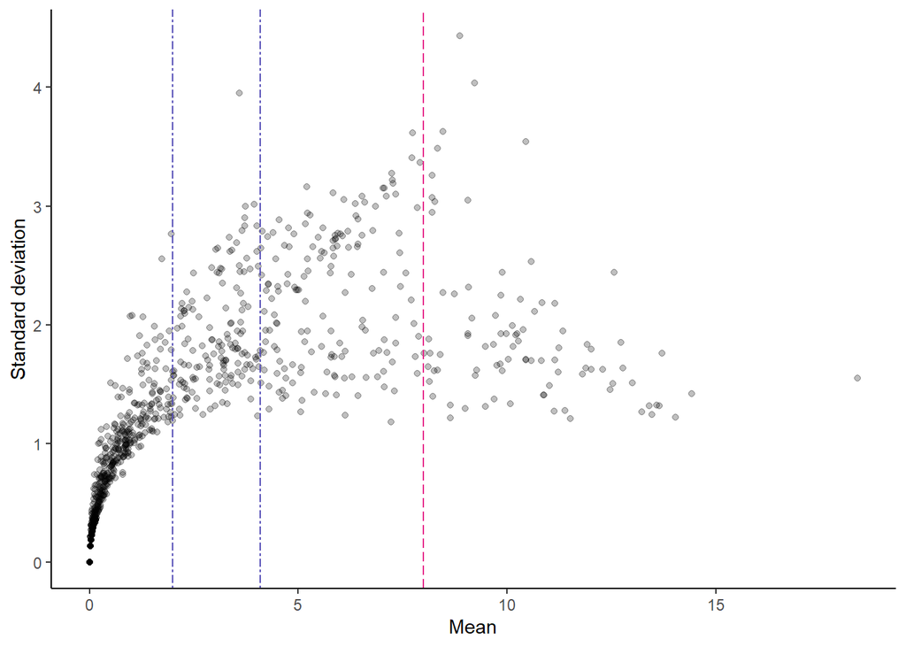

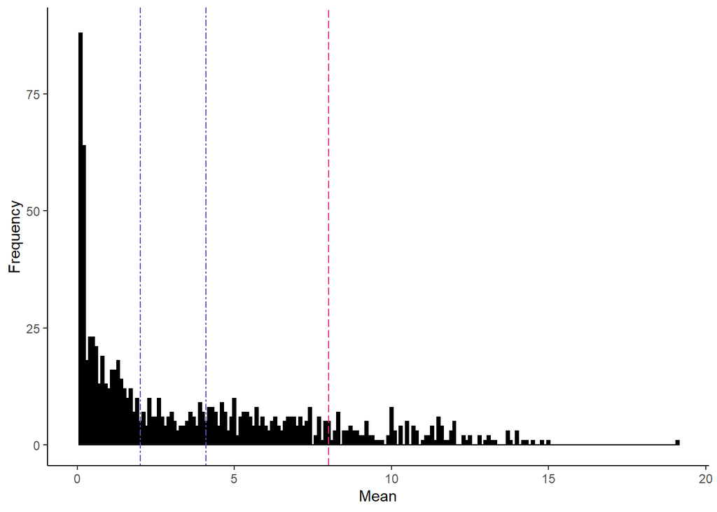

```
## 313 genes has been filtered because they contains too small number of reads across the experiments.Number of positive control markers with RC in [128, inf): 115
## Number of negative control markers with RC in [2, 10]: 102
## Number of positive control markers with RC in [64, inf): 150
## Number of negative control markers with RC in [1.5, 5]: 92
## Number of positive control markers with RC in [256, inf): 77
## Number of negative control markers with RC in [3, 16]: 103
## Estimating correlations for pos. and neg. controls for data set config1...done
## Estimating correlations for pos. and neg. controls for data set test.TMM...done
## Estimating correlations for pos. and neg. controls for data set test.DESeq...done
## Estimating correlations for pos. and neg. controls for data set test.PoissonSeq...done
## Estimating correlations for pos. and neg. controls for data set test.TC...done
## Estimating correlations for pos. and neg. controls for data set test.Med...done
## Estimating correlations for pos. and neg. controls for data set test.RUVg...done
## Estimating correlations for pos. and neg. controls for data set test.RUVs...done
## Estimating correlations for pos. and neg. controls for data set test.RUVr...done
## Estimating correlations for pos. and neg. controls for data set test.UQ...done
## Estimating correlations for pos. and neg. controls for data set test.QN...done
## Comparing models config1 vs. test.TMM....done
## Comparing models config1 vs. test.DESeq....done
## Comparing models config1 vs. test.PoissonSeq....done
## Comparing models config1 vs. test.TC....done
## Comparing models config1 vs. test.Med....done
## Comparing models config1 vs. test.RUVg....done
## Comparing models config1 vs. test.RUVs....done
## Comparing models config1 vs. test.RUVr....done
## Comparing models config1 vs. test.UQ....done
## Comparing models config1 vs. test.QN....done
## Estimating correlations for pos. and neg. controls for data set config2...done
## Estimating correlations for pos. and neg. controls for data set test.TMM...done
## Estimating correlations for pos. and neg. controls for data set test.DESeq...done
## Estimating correlations for pos. and neg. controls for data set test.PoissonSeq...done
## Estimating correlations for pos. and neg. controls for data set test.TC...done
## Estimating correlations for pos. and neg. controls for data set test.Med...done
## Estimating correlations for pos. and neg. controls for data set test.RUVg...done
## Estimating correlations for pos. and neg. controls for data set test.RUVs...done
## Estimating correlations for pos. and neg. controls for data set test.RUVr...done
## Estimating correlations for pos. and neg. controls for data set test.UQ...done
## Estimating correlations for pos. and neg. controls for data set test.QN...done
## Comparing models config2 vs. test.TMM....done
## Comparing models config2 vs. test.DESeq....done
```

[output cut: 14 more lines]

```
## Estimating correlations for pos. and neg. controls for data set test.RUVg...done
## Estimating correlations for pos. and neg. controls for data set test.RUVs...done
## Estimating correlations for pos. and neg. controls for data set test.RUVr...done
## Estimating correlations for pos. and neg. controls for data set test.UQ...done
## Estimating correlations for pos. and neg. controls for data set test.QN...done
## Comparing models config3 vs. test.TMM....done
## Comparing models config3 vs. test.DESeq....done
## Comparing models config3 vs. test.PoissonSeq....done
## Comparing models config3 vs. test.TC....done
## Comparing models config3 vs. test.Med....done
## Comparing models config3 vs. test.RUVg....done
## Comparing models config3 vs. test.RUVs....done
## Comparing models config3 vs. test.RUVr....done
## Comparing models config3 vs. test.UQ....done
## Comparing models config3 vs. test.QN....done
```

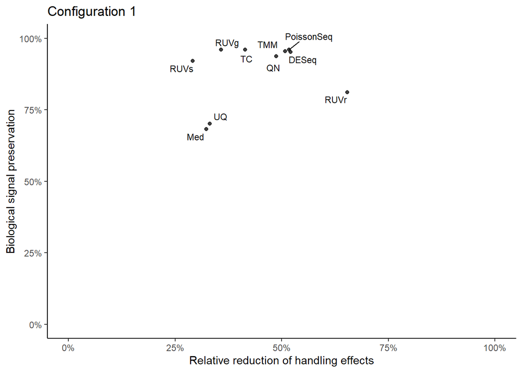

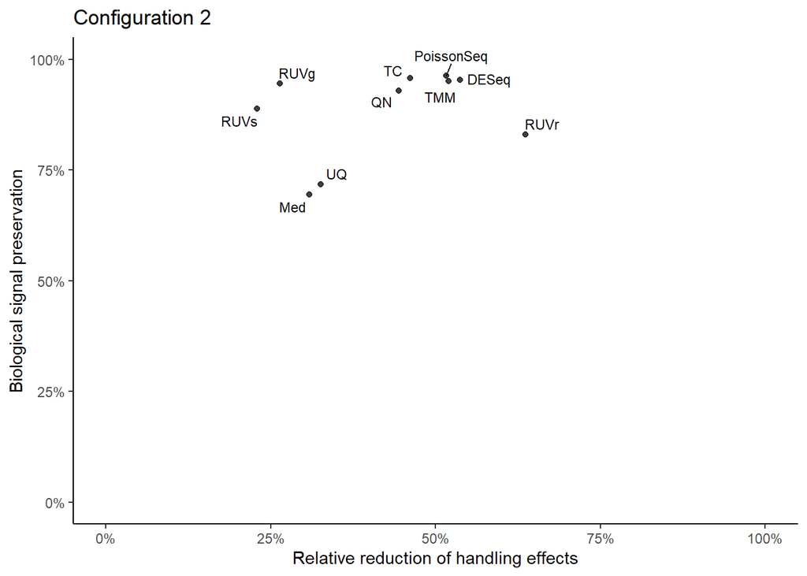

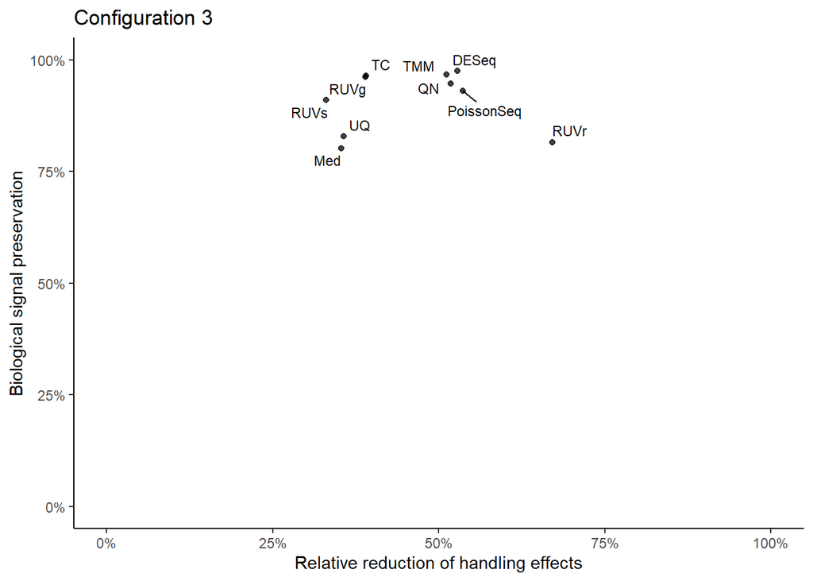

```r
if(settings$compare.cutoffs) {
  ## Configuration of three possible cutoff choices
  cutoff.conf1 <- list(
    t.zero = 2,  # zero-expressed in [0, t.zero)
    t.poor = 10,  # poorly-expressed in [t.zero, t.poor]
    t.well = 2^7  # well-expressed in [t.well, inf)
  )
  cutoff.conf2 <- list(
    t.zero = 1.5,  # zero-expressed in [0, t.zero)
    t.poor = 5,  # poorly-expressed in [t.zero, t.poor]
    t.well = 2^6  # well-expressed in [t.well, inf)
  )
  cutoff.conf3 <- list(
    t.zero = 3,  # zero-expressed in [0, t.zero)
    t.poor = 16,  # poorly-expressed in [t.zero, t.poor]
    t.well = 2^8  # well-expressed in [t.well, inf)
  )

  p.meanvar.conf1 <- plot.mean.sd(test.RC, cutoff.conf1$t.zero,
                                  cutoff.conf1$t.poor, cutoff.conf1$t.well)
  print(p.meanvar.conf1)
  p.RC.conf1 <- plot.countHist(test.RC, binwidth = 0.1, cutoff.conf1$t.zero,
                               cutoff.conf1$t.poor, cutoff.conf1$t.well)
  print(p.RC.conf1)

  p.meanvar.conf2 <- plot.mean.sd(test.RC, cutoff.conf2$t.zero,
                                  cutoff.conf2$t.poor, cutoff.conf2$t.well)
  print(p.meanvar.conf2)
  p.RC.conf2 <- plot.countHist(test.RC, binwidth = 0.1, cutoff.conf2$t.zero,
                               cutoff.conf2$t.poor, cutoff.conf2$t.well)
  print(p.RC.conf2)

  p.meanvar.conf3 <- plot.mean.sd(test.RC, cutoff.conf3$t.zero,
                                  cutoff.conf3$t.poor, cutoff.conf3$t.well)
  print(p.meanvar.conf3)
  p.RC.conf3 <- plot.countHist(test.RC, binwidth = 0.1, cutoff.conf3$t.zero,
                               cutoff.conf3$t.poor, cutoff.conf3$t.well)
  print(p.RC.conf3)


  ## Apply Normalization
  test.norm <- normalize(test.RC,
                         groups=groups,
                         name="test",
                         apply.TC=config$norm.apply.TC,
                         apply.UQ=config$norm.apply.UQ,
                         apply.med=config$norm.apply.med,
                         apply.TMM=config$norm.apply.TMM,
                         apply.DESeq=config$norm.apply.DESeq,
                         apply.PoissonSeq=config$norm.apply.PoissonSeq,
                         apply.QN=config$norm.apply.QN,
                         apply.RUV=config$norm.apply.RUV)

  ## Define Controls

  # config 1
  cutoffs.1 <- define.controls(test.RC,
                               t.zero=cutoff.conf1$t.zero,
                               t.poor=cutoff.conf1$t.poor,
                               t.well=cutoff.conf1$t.well,
                               t.cluster=config$cluster.threshold,
                               coords=coords,
                               clusters=NULL)
  pos.controls.1 <- cutoffs.1$genes.pos
  neg.controls.1 <- cutoffs.1$genes.neg
  clusters <- cutoffs.1$clusters

  # config 2
  cutoffs.2 <- define.controls(test.RC,
                               t.zero=cutoff.conf2$t.zero,
                               t.poor=cutoff.conf2$t.poor,
                               t.well=cutoff.conf2$t.well,
                               t.cluster=config$cluster.threshold,
                               coords=coords,
                               clusters=NULL)
  pos.controls.2 <- cutoffs.2$genes.pos
  neg.controls.2 <- cutoffs.2$genes.neg


  # config 3
  cutoffs.3 <- define.controls(test.RC,
                               t.zero=cutoff.conf3$t.zero,
                               t.poor=cutoff.conf3$t.poor,
                               t.well=cutoff.conf3$t.well,
                               t.cluster=config$cluster.threshold,
                               coords=coords,
                               clusters=NULL)
  pos.controls.3 <- cutoffs.3$genes.pos
  neg.controls.3 <- cutoffs.3$genes.neg



  ## Apply DANA pipeline

  # Config 1
  DANA.1 <- DANA(data.RC=test.RC,
                 data.norm=test.norm,
                 pos.controls=pos.controls.1,
                 neg.controls=neg.controls.1,
                 clusters=clusters,
                 coords=coords,
                 case.name="config1",
                 generate.plots=FALSE,
                 preprocess.transform=config$preprocess.transform,
                 corr.method.pos=config$corr.method.pos,
                 tuning.criterion.pos=config$tuning.criterion.pos,
                 corr.method.neg=config$corr.method.neg,
                 tuning.criterion.neg=config$tuning.criterion.neg)
  rownames(DANA.1$metrics) <- substr(rownames(DANA.1$metrics), 6, 20)

  # Config 2
  DANA.2 <- DANA(data.RC=test.RC,
                 data.norm=test.norm,
                 pos.controls=pos.controls.2,
                 neg.controls=neg.controls.2,
                 clusters=clusters,
                 coords=coords,
                 case.name="config2",
                 generate.plots=FALSE,
                 preprocess.transform=config$preprocess.transform,
                 corr.method.pos=config$corr.method.pos,
                 tuning.criterion.pos=config$tuning.criterion.pos,
                 corr.method.neg=config$corr.method.neg,
                 tuning.criterion.neg=config$tuning.criterion.neg)
  rownames(DANA.2$metrics) <- substr(rownames(DANA.2$metrics), 6, 20)

  # Config 3
  DANA.3 <- DANA(data.RC=test.RC,
                 data.norm=test.norm,
                 pos.controls=pos.controls.3,
                 neg.controls=neg.controls.3,
                 clusters=clusters,
                 coords=coords,
                 case.name="config3",
                 generate.plots=FALSE,
                 preprocess.transform=config$preprocess.transform,
                 corr.method.pos=config$corr.method.pos,
                 tuning.criterion.pos=config$tuning.criterion.pos,
                 corr.method.neg=config$corr.method.neg,
                 tuning.criterion.neg=config$tuning.criterion.neg)
  rownames(DANA.3$metrics) <- substr(rownames(DANA.3$metrics), 6, 20)

  # Plot results

  p.result.DANA.1 <- plot.DANA.metrics(DANA.1$metrics, label.repel = TRUE)
  plot(p.result.DANA.1 + ggtitle("Configuration 1"))
  p.result.DANA.2 <- plot.DANA.metrics(DANA.2$metrics, label.repel = TRUE)
  plot(p.result.DANA.2 + ggtitle("Configuration 2"))
  p.result.DANA.3 <- plot.DANA.metrics(DANA.3$metrics, label.repel = TRUE)
  plot(p.result.DANA.3 + ggtitle("Configuration 3"))
}
```

# Differential Expression Analysis

## Normalize Data

```r
if(settings$perform.DEA) {
  ## Reset data
  test.RC <- test
  bench.RC <- benchmark

  ## Normalize test Data
  test.norm <- normalize(test.RC,
                         groups=groups,
                         name="test",
                         apply.TC=config.DEA$norm.apply.TC,
                         apply.UQ=config.DEA$norm.apply.UQ,
                         apply.med=config.DEA$norm.apply.med,
                         apply.TMM=config.DEA$norm.apply.TMM,
                         apply.DESeq=config.DEA$norm.apply.DESeq,
                         apply.PoissonSeq=config.DEA$norm.apply.PoissonSeq,
                         apply.QN=config.DEA$norm.apply.QN,
                         apply.RUV=FALSE)
  test.norm.RUV.adjust <- list(test.RUVr=norm.RUV(test.RC, groups, "RUVr")$adjust.factor,
                               test.RUVs=norm.RUV(test.RC, groups, "RUVs")$adjust.factor,
                               test.RUVg=norm.RUV(test.RC, groups, "RUVg")$adjust.factor)
}
```

```
## 328 genes has been filtered because they contains too small number of reads across the experiments.
```

## Benchmark DEA

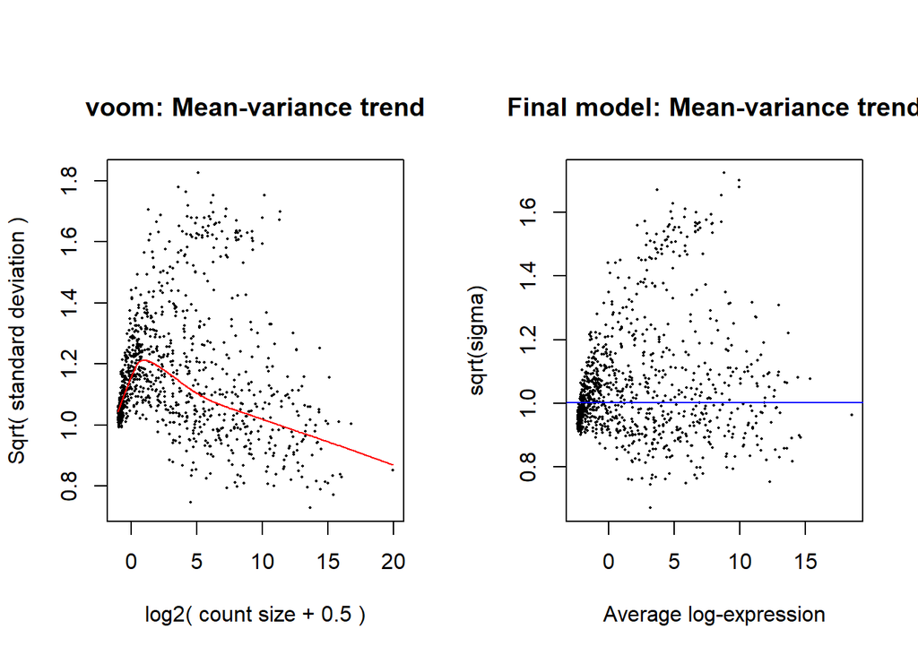

```
## number of DE genes: 59
```

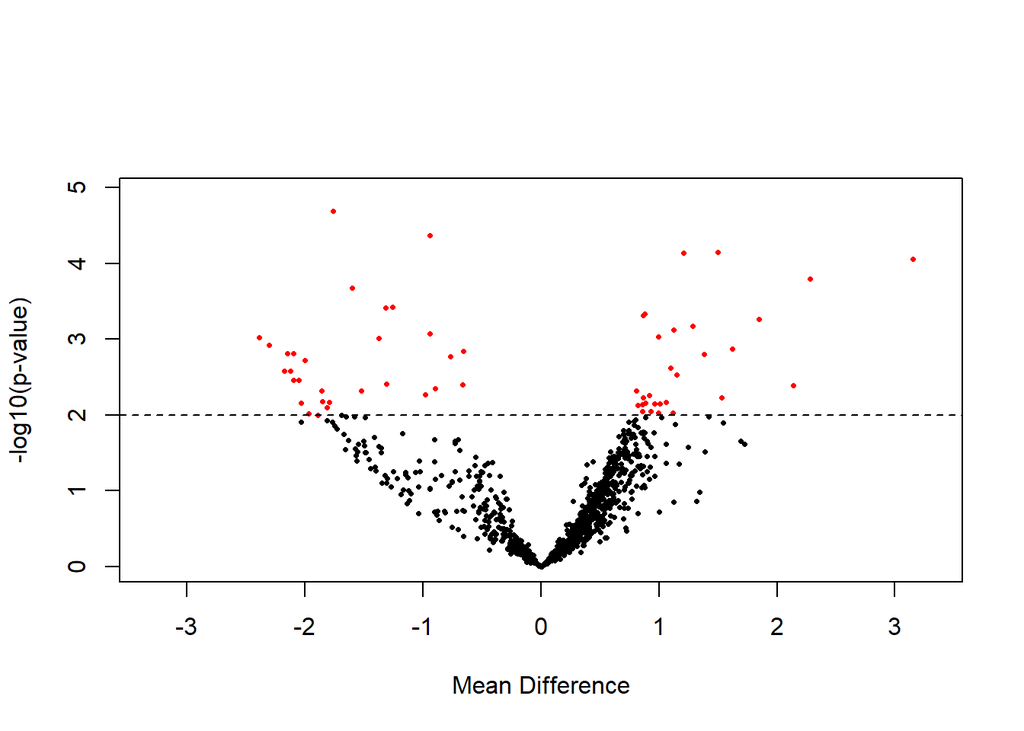

```r
if(settings$perform.DEA) {
  ## Perform DEA on benchmark dataset
  bench.DEA <- DE.voom(data.RC=bench.RC, groups=groups, plot=config.DEA$generate.meanvar.plot)
  if(config.DEA$generate.volcano.plot) plot.DE.volcano(bench.DEA, alpha=config.DEA$alpha, q.values=config.DEA$q.values)
}
```

## Test DEA

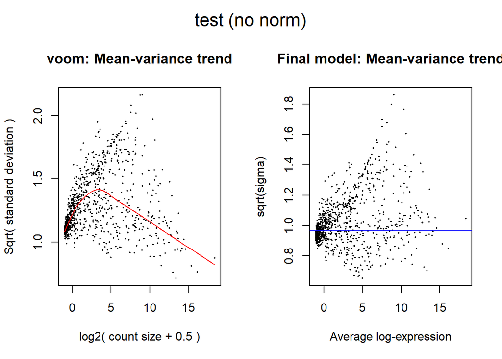

```
## number of DE genes: 70
```

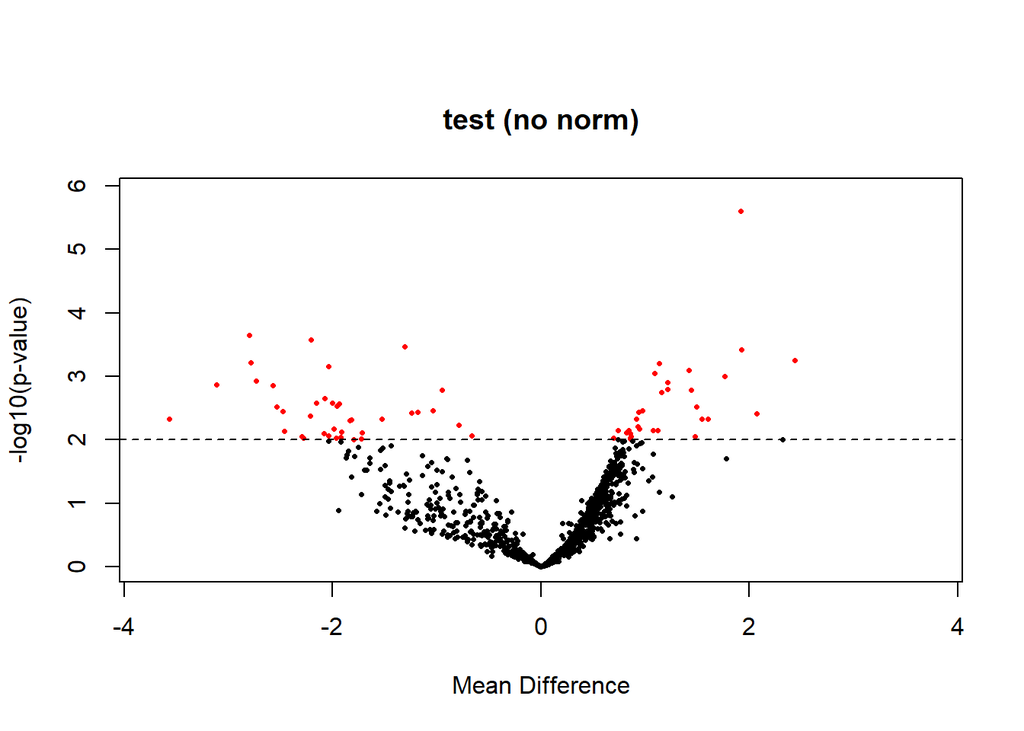

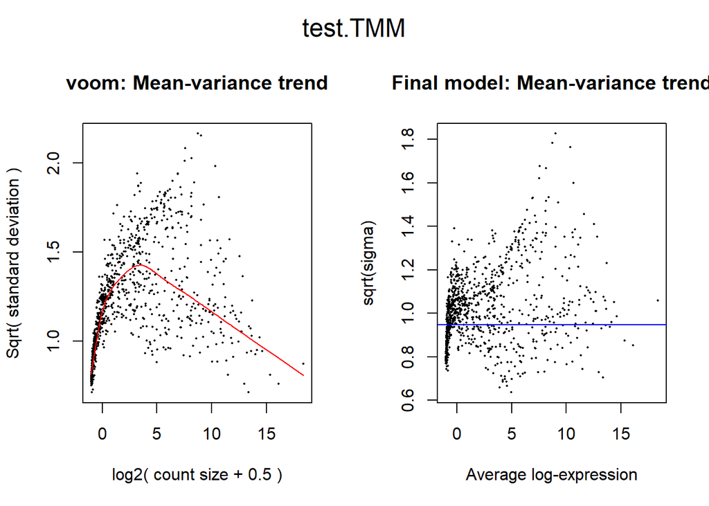

```
## number of DE genes: 39
```

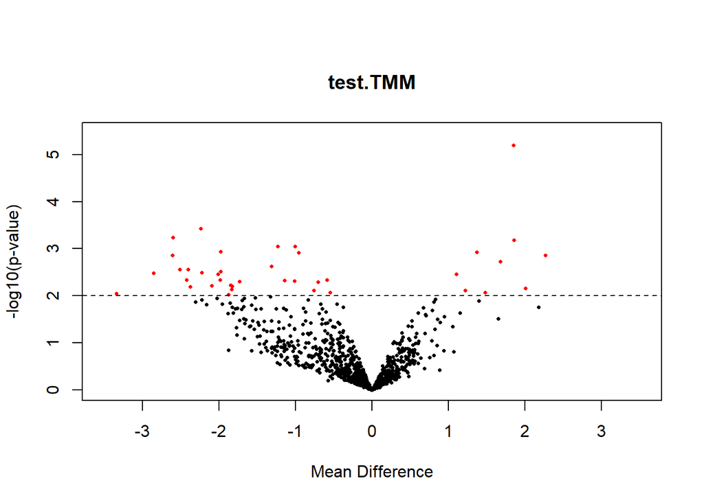

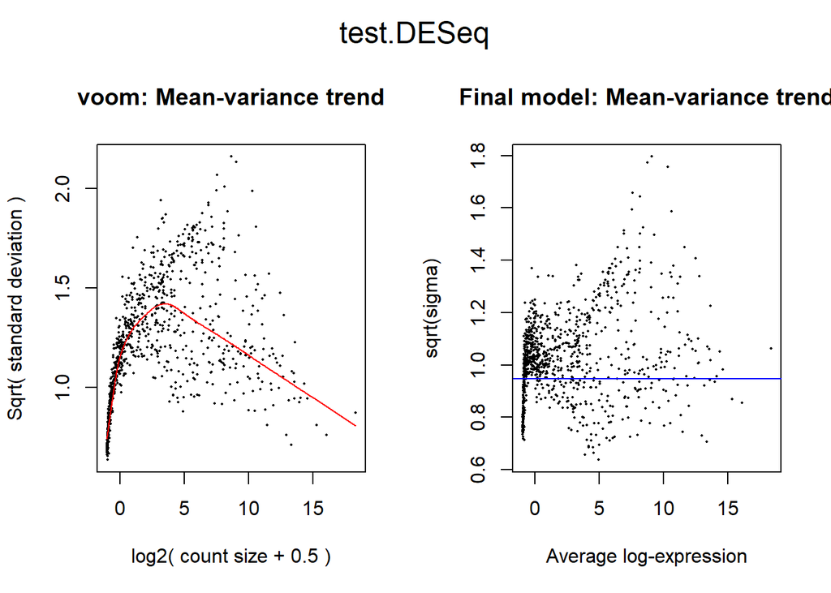

```
## number of DE genes: 52
```

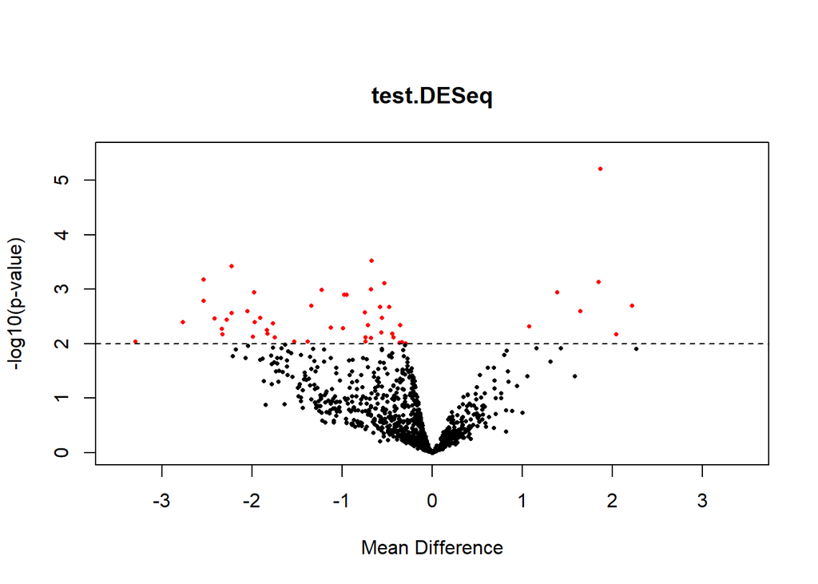

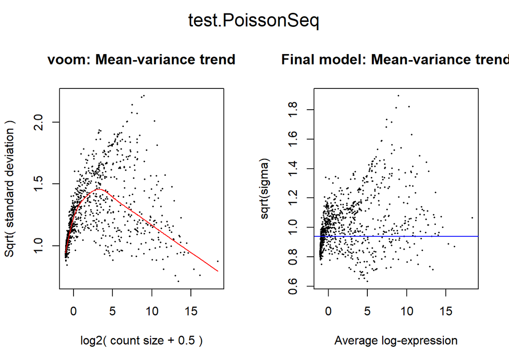

```
## number of DE genes: 39
```

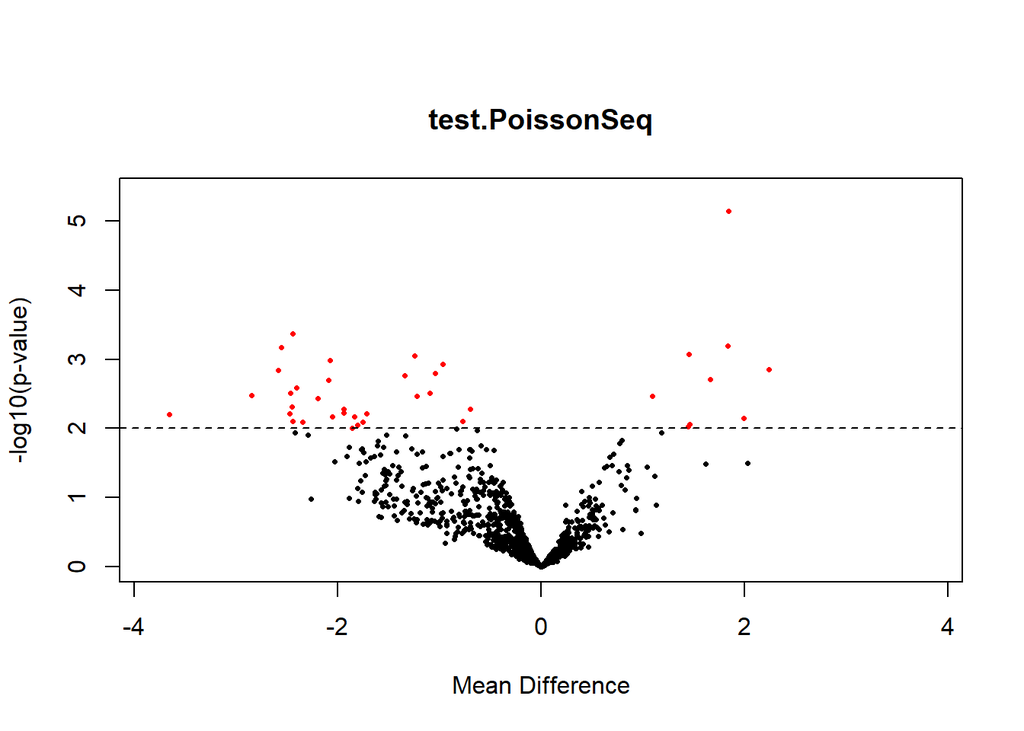

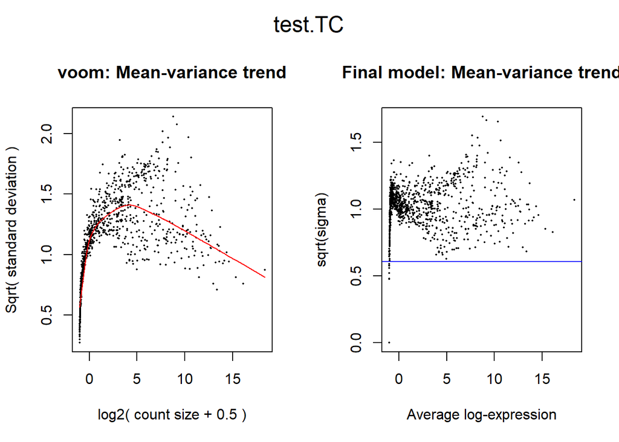

```
## number of DE genes: 49
```

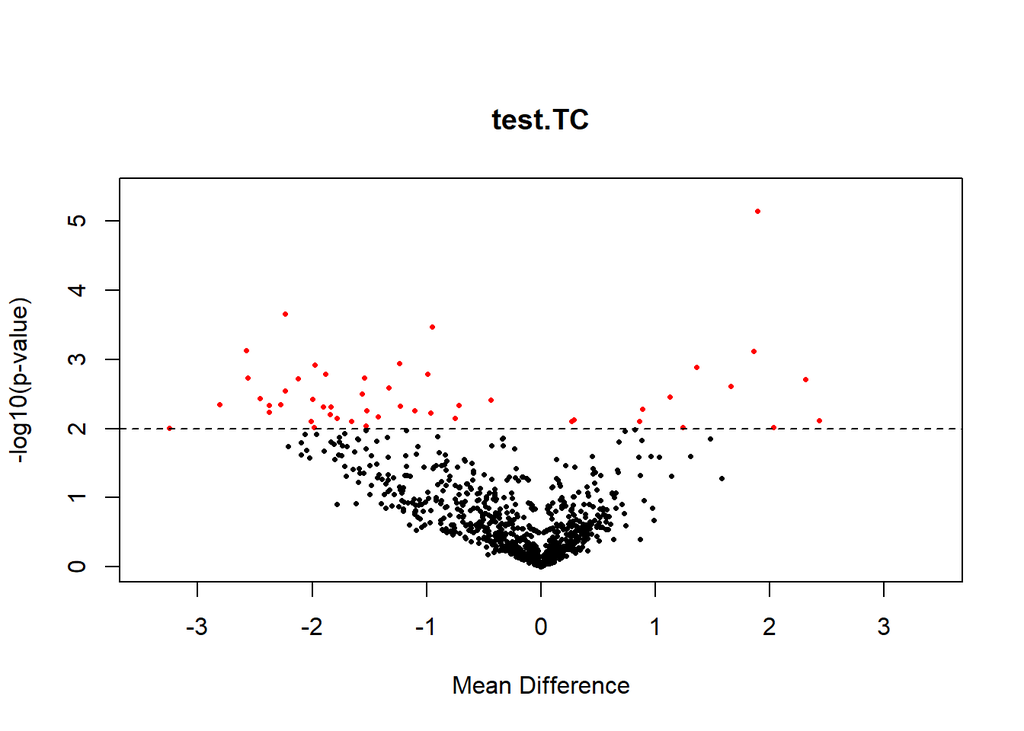

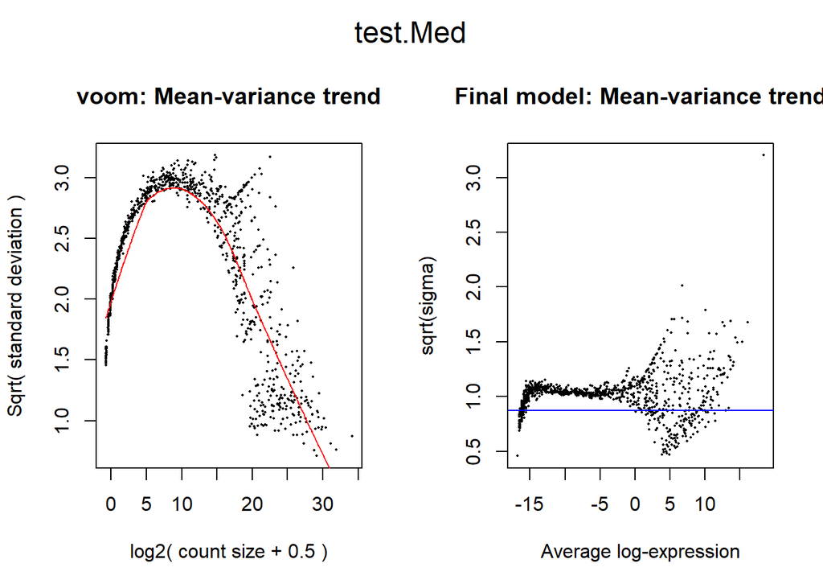

```
## number of DE genes: 54
```

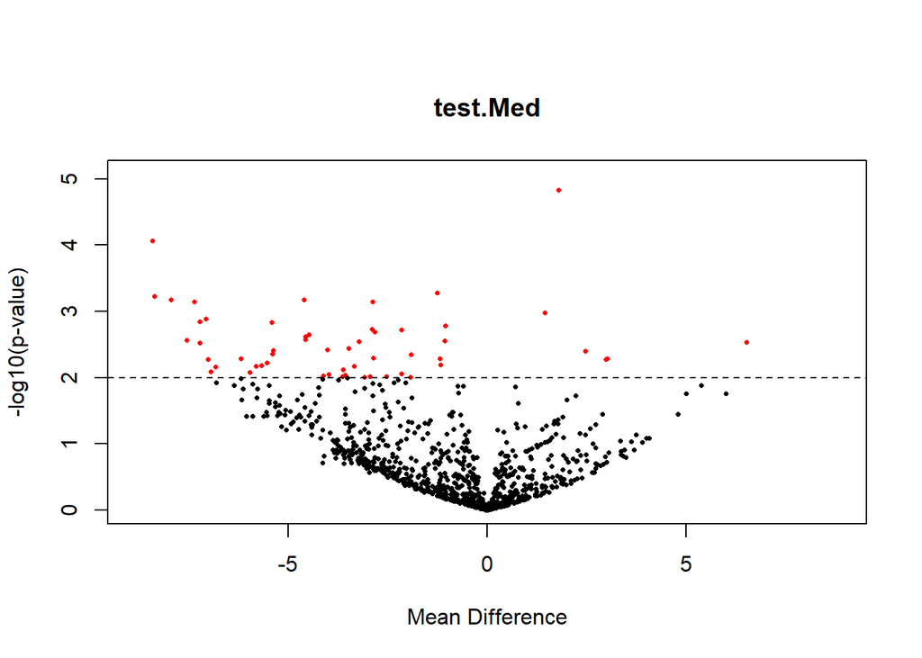

[10 more figures not shown]

```r
if(settings$perform.DEA) {
  ## Perform DEA on full dataset
  test.DEA <- DE.voom(data.RC=test.RC, groups=groups, plot=config.DEA$generate.meanvar.plot, plot.title="test (no norm)")
  if(config.DEA$generate.volcano.plot) plot.DE.volcano(test.DEA, alpha=config.DEA$alpha, q.values=config.DEA$q.values, title="test (no norm)")

  ## DEA for normalized test data
  test.norm.DEA <- list()
  for(i in 1:length(test.norm)) {
    test.norm.DEA <-
      append(test.norm.DEA, list(DE.voom(data.RC=test.norm[[i]],
                                         groups=groups,
                                         plot=config.DEA$generate.meanvar.plot,
                                         plot.title=names(test.norm)[i])))
    if(config.DEA$generate.volcano.plot) {
      plot.DE.volcano(test.norm.DEA[[i]],
                      alpha=config.DEA$alpha,
                      q.values=config.DEA$q.values,
                      title=names(test.norm)[i])
    }
  }
  ## DEA for RUV normalization
  for(i in 1:length(test.norm.RUV.adjust)) {
    test.norm.DEA <-
      append(test.norm.DEA, list(DE.voom(data.RC=test.RC,
                                         groups=groups,
                                         plot=config.DEA$generate.meanvar.plot,
                                         plot.title=names(test.norm.RUV.adjust)[i],
                                         adjust=test.norm.RUV.adjust[[i]])))
    if(config.DEA$generate.volcano.plot) {
      plot.DE.volcano(test.norm.DEA[[i]],
                      alpha=config.DEA$alpha,
                      q.values=config.DEA$q.values,
                      title=names(test.norm.RUV.adjust)[i])
    }
  }
  names(test.norm.DEA) <- c(names(test.norm), names(test.norm.RUV.adjust))
}
```

## Results

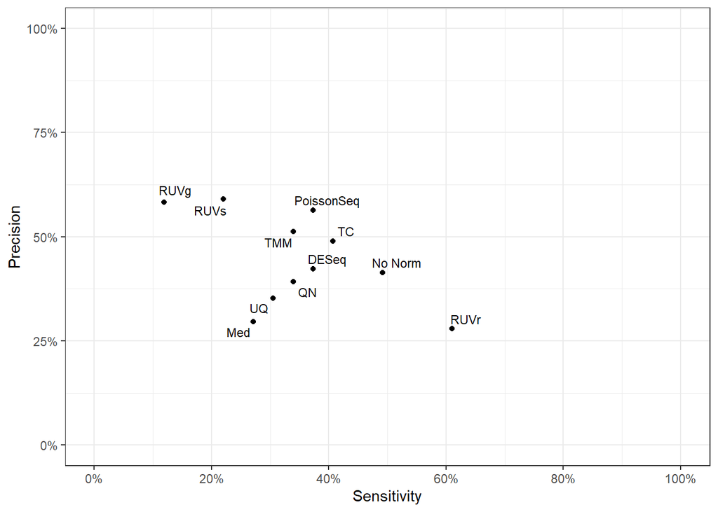

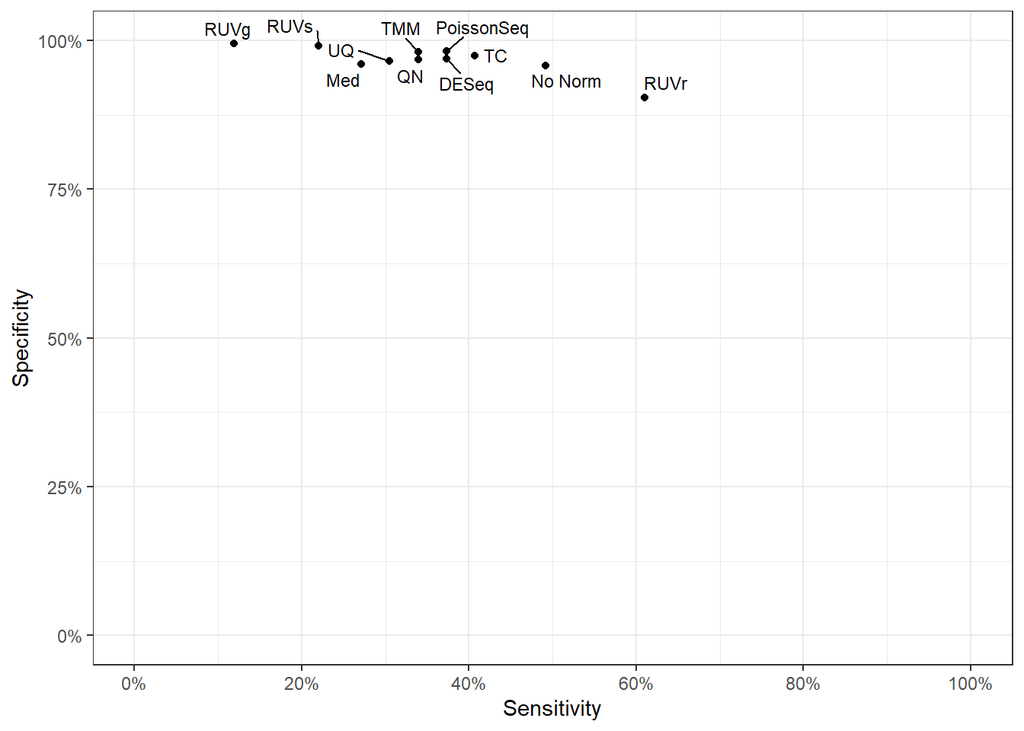

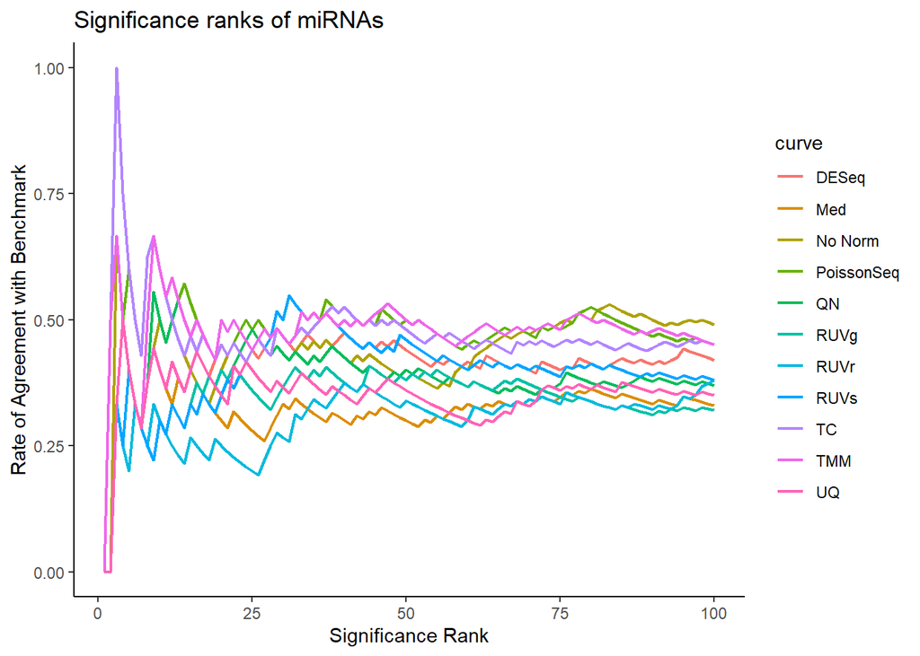

```r
if(settings$perform.DEA) {
  ## Compare test (non-norm) to benchmark
  test.norm.DEA.stats <- list(test=compare.DEAs(DEA=test.DEA,
                                           truth.DEA=bench.DEA,
                                           alpha=config.DEA$alpha))
  ## Compare normalized test data to benchmark
  for(i in 1:length(test.norm.DEA)) {
    test.norm.DEA.stats <-
      append(test.norm.DEA.stats,
             list(compare.DEAs(DEA=test.norm.DEA[[i]],
                               truth.DEA=bench.DEA,
                               alpha=config.DEA$alpha,
                               subset=switch(config.DEA$perform.subsetting+1,
                                             NULL,
                                             rownames(test.norm.DEA[[i]])))))
  }
  names(test.norm.DEA.stats) <- c("test.No Norm", names(test.norm.DEA))
  test.norm.DEA.stats <- test.norm.DEA.stats[1:length(test.norm.DEA.stats)]


  ## Visualize results

  # FNR-FDR Plot
  test.DEA.res <- data.frame(method=substr(names(test.norm.DEA.stats), 6, 20),
                             FDR=-sapply(test.norm.DEA.stats, function(x) x$FDR)+1,
                             FNR=-sapply(test.norm.DEA.stats, function(x) x$FNR)+1)
  p.test.DEA.FNR.FDR <- ggplot(test.DEA.res, aes(x=FNR, y=FDR, label=method)) +
      theme_bw() +
      geom_point(alpha=1) +
      xlab("Sensitivity") + # True positive rate(1-FNR)
      ylab("Precision") + # Positive predictive value (1-FDR)
      geom_text_repel(aes(label = method), size=3) +
      scale_x_continuous(labels = scales::percent, limits=c(0,1),
                         breaks = scales::pretty_breaks(n = 4)) +
      scale_y_continuous(labels = scales::percent, limits = c(0,1))
  print(p.test.DEA.FNR.FDR)

  # TPR-FPR Plot
  test.DEA.res <- data.frame(method=substr(names(test.norm.DEA.stats), 6, 20),
                             TPR=sapply(test.norm.DEA.stats, function(x) x$TPR),
                             FPR=-sapply(test.norm.DEA.stats, function(x) x$FPR)+1)
  p.test.DEA.TPR.FPR <- ggplot(test.DEA.res, aes(x=TPR, y=FPR, label=method)) +
      theme_bw() +
      geom_point(alpha=1) +
      xlab("Sensitivity") +
      ylab("Specificity") +
      geom_text_repel(aes(label = method), size=3) +
      scale_x_continuous(labels = scales::percent, limits=c(0,1),
                         breaks = scales::pretty_breaks(n = 4)) +
      scale_y_continuous(labels = scales::percent, limits = c(0,1))
  print(p.test.DEA.TPR.FPR)

  # CAT Plot
  d <- append(list("test.No Norm"=test.DEA), test.norm.DEA)
  names(d) <- substr(names(d), 6, 20)
  p.test.DEA.CAT <- plot.CAT(DEA=d,
                             truth.DEA=bench.DEA,
                             title="Significance ranks of miRNAs",
                             maxrank=100)
  print(p.test.DEA.CAT)
  rm(d)
}
```

# Results and Figures for Paper

## Number of samples, markers, and positive and negative controls

```r
if(settings$generate.paper.figs) {

# Dimension of data after analysis
cat("Test data:\n")
cat("  - Dimensions: p=", dim(test.RC)[1],", n=", dim(test.RC)[2], "\n", sep="")
cat("  - Positive controls:\n")
cat("    * Definition mean RC in interval: [", config$t.well, ", inf ]\n", sep="")
cat("    * Number of positive controls miRNAs:", length(pos.controls.test), "\n")
cat("  - Negative controls:\n")
cat("    * Definition mean RC in interval: [", config$t.zero, ",", config$t.poor, "]\n")
cat("    * Number of negative controls miRNAs:", length(neg.controls.test), "\n")


cat("\n\nBenchmark data:\n")
cat("  - Dimensions: p=", dim(bench.RC)[1],", n=", dim(bench.RC)[2], "\n", sep="")
cat("  - Positive controls:\n")
cat("    * Definition mean RC in interval: [", config$t.well, ", inf ]\n", sep="")
cat("    * Number of positive controls miRNAs:", length(pos.controls.bench), "\n")
cat("  - Negative controls:\n")
cat("    * Definition mean RC in interval: [", config$t.zero, ",", config$t.poor, "]\n")
cat("    * Number of negative controls miRNAs:", length(neg.controls.bench), "\n")

}
```

```
## Test data:
##   - Dimensions: p=1033, n=54
##   - Positive controls:
##     * Definition mean RC in interval: [128, inf ]
##     * Number of positive controls miRNAs: 115
##   - Negative controls:
##     * Definition mean RC in interval: [ 2 , 10 ]
##     * Number of negative controls miRNAs: 102
##
##
## Benchmark data:
##   - Dimensions: p=1033, n=54
##   - Positive controls:
##     * Definition mean RC in interval: [128, inf ]
##     * Number of positive controls miRNAs: 179
##   - Negative controls:
##     * Definition mean RC in interval: [ 2 , 10 ]
##     * Number of negative controls miRNAs: 120
```

## Read Count Distribution in the Data

### Per Data-Set

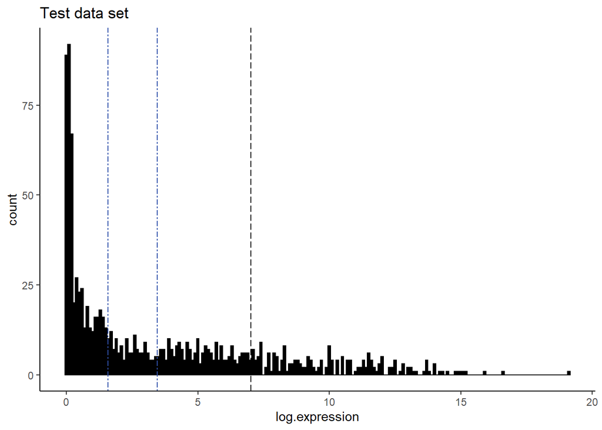

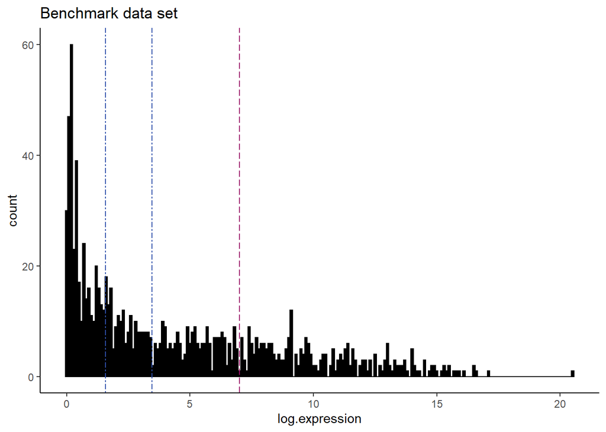

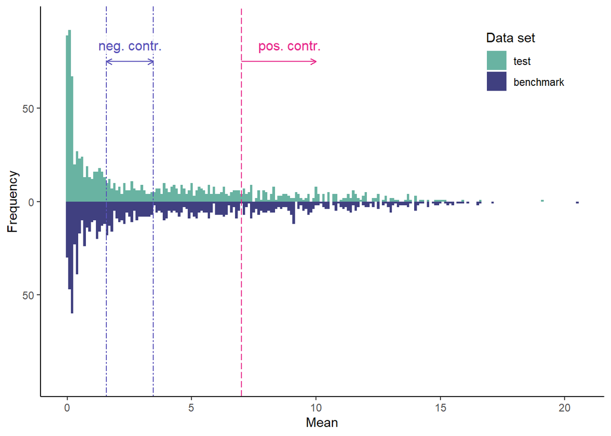

```r
if(settings$generate.paper.figs) {
  par(mfrow=c(1,1))

  # Histogram plot test data set
  test.RC.log2 <- log2(rowMeans(test.RC)+1)
  df <- data.frame(log.expression=test.RC.log2)
  p.test.RC.hist <- ggplot(df, aes(x=log.expression)) +
    geom_histogram(binwidth = .1, color="black", fill="black") +
    geom_vline(xintercept = log2(config$t.zero+1), color="#3051ab", linetype="twodash") +
    geom_vline(xintercept = log2(config$t.poor+1), color="#3051ab", linetype="twodash") +
    geom_vline(xintercept = log2(config$t.well+1), color="9e086c",  linetype="longdash") +
    ggtitle("Test data set") +
    theme_classic()
  print(p.test.RC.hist)
  rm(df)


  # Histogram plot benchmark data set
  bench.RC.log2 <- log2(rowMeans(bench.RC)+1)
  df <- data.frame(log.expression=bench.RC.log2)
  p.bench.RC.hist <- ggplot(df, aes(x=log.expression)) +
    geom_histogram(binwidth = .1, color="black", fill="black") +
    geom_vline(xintercept = log2(config$t.zero+1), color="#3051ab", linetype="twodash") +
    geom_vline(xintercept = log2(config$t.poor+1), color="#3051ab", linetype="twodash") +
    geom_vline(xintercept = log2(config$t.well+1), color="#9e086c",  linetype="longdash") +
    ggtitle("Benchmark data set") +
    theme_classic()
  print(p.bench.RC.hist)
  rm(df)


  # Combined read count histogram for test and benchmark data
  df <- data.frame(bench=bench.RC.log2, test=test.RC.log2)
  p.RC.hist <- ggplot(df) +
    theme_classic() +
    geom_histogram(aes(x=test, y=..count..,fill="#69b3a2"), binwidth = .1) +
    geom_histogram(aes(x=bench, y=-..count.., fill="#404080"), binwidth = .1) +
    geom_vline(xintercept = log2(config$t.zero+1), color="#5851b8", linetype="twodash") +
    geom_vline(xintercept = log2(config$t.poor+1), color="#5851b8", linetype="twodash") +
    geom_vline(xintercept = log2(config$t.well+1), color="#E7298A",  linetype="longdash") +
    geom_segment(aes(x = log2(config$t.zero+1), y = 75, xend = log2(config$t.poor+1), yend = 75),
                 arrow=arrow(length=unit(.07, "in"), ends="both"),
                 color="#5851b8") +
    annotate(geom="label", x=(log2(config$t.zero+1)+log2(config$t.poor+1))/2.0, y=84,
             label="neg. contr.", color="#5851b8", size=4, fill = alpha(c("white"),0.85), label.size = NA) +
    geom_segment(aes(x = log2(config$t.well+1), y = 75, xend = 10, yend = 75),
                 arrow=arrow(length=unit(.07, "in"), ends="last"),
                 color="#E7298A") +
    annotate(geom="label", x=log2(config$t.well+1)+.5, y=84,
             label="pos. contr.", color="#E7298A", size=4, hjust=0, fill = alpha(c("white"),0.85), label.size = NA) +
    # ylim(c(-90,90)) +
    scale_fill_manual(name="Data set",values=c("#404080", "#69b3a2"), labels=c("benchmark", "test"), guide = guide_legend(reverse=TRUE)) +
    # ggtitle("log2(Read count + 1)") +
    theme(legend.position=c(0.86,0.86),
          # legend.title=element_blank(),
          legend.background=element_rect(fill=alpha('white', 0.9))) +
    scale_y_continuous(breaks=c(-50,0,50), labels=c(50,0,50), limits=c(-95,95)) +
    xlab("Mean") +
    ylab("Frequency")
    # theme(panel.border = element_blank(),
    #       axis.line = element_line(color = 'black'))
  print(p.RC.hist)
  rm(df)

    ## Export Plots
  if(settings$export.figures) {
    ggsave(paste0(settings$paper.fig.path, "MSK_RC_Distribution.pdf"), p.RC.hist, width = 5, height=4, device="pdf")
  }

}
```